# 1.智能体

##### 3）handle_errors设置为“请检查输入数据”

运行后结果如下：

```python
from pydantic import BaseModel, Field
from typing import Union
from langchain.agents import create_agent
from langchain.agents.structured_output import ToolStrategy
from rich import print as rprint

class ContactInfo(BaseModel):
    """个人联系信息"""
    name: str = Field(description="姓名")
    email: str = Field(description="电子邮箱")

class EventDetails(BaseModel):
    """活动详情"""
    event_name: str = Field(description="活动名称")
    date: str = Field(description="活动日期")

agent = create_agent(
    model=model_bailian,
    response_format=ToolStrategy(
        Union[ContactInfo, EventDetails],
        tool_message_content="提取完成！",
        handle_errors="请检查输入数据"
    )
)

result = agent.invoke({
    "messages":[{
        "role":"user",
        "content":f"请提取以下文本中内容：姓名：张三，电子邮箱：zhang3@atguigu.com，活动名称：公司年会，活动日期：2026-07-15"
    }]
})

rprint(result)
```

```
{
    'messages': [
        HumanMessage(
            content='请提取以下文本中内容：姓名：张三，电子邮箱：zhang3@atguigu.com，活动名称：公司年会，活动日期：
2026-07-15',
            additional_kwargs={},
            response_metadata={},
            id='671250a4-1662-4f78-945a-1ea423af7bf7'
        ),
        AIMessage(
            content='',
            additional_kwargs={'refusal': None},
            response_metadata={
                'token_usage': {
                    'completion_tokens': 118,
                    'prompt_tokens': 404,
                    'total_tokens': 522,
                    'completion_tokens_details': None,
                    'prompt_tokens_details': {'audio_tokens': None, 'cached_tokens': 256}
                },
                'model_provider': 'openai',
                'model_name': 'deepseek-v4-flash-0731',
                'system_fingerprint': None,
                'id': 'chatcmpl-bddefd48-968c-975a-a4e3-c1a5bbd8be34',
                'finish_reason': 'tool_calls',
                'logprobs': None
            },
            id='lc_run--019ff646-021b-72c0-9ca2-23968458471c-0',
            tool_calls=[
                {
                    'name': 'ContactInfo',
                    'args': {'email': 'zhang3@atguigu.com', 'name': '张三'},
                    'id': 'call_c4c0c568ff514df58078a41b',
                    'type': 'tool_call'
                },
                {
                    'name': 'EventDetails',
                    'args': {'date': '2026-07-15', 'event_name': '公司年会'},
                    'id': 'call_0ba1d4cbd2b0462592e06fd6',
                    'type': 'tool_call'
```

[output cut: 269 more lines]

```
                'output_tokens': 65,
                'total_tokens': 1204,
                'input_token_details': {'cache_read': 512},
                'output_token_details': {}
            }
        ),
        ToolMessage(
            content='提取完成！',
            name='ContactInfo',
            id='be18fc6b-907e-4ff8-be23-f3fbc7f430d8',
            tool_call_id='call_52e97821019c496b9e74ffc8'
        )
    ],
    'structured_response': ContactInfo(name='张三', email='zhang3@atguigu.com')
}
```

以上代码中注意如下几点：

1. ToolStrategy允许指定多个类型“Union[ContactInfo, EventDetails]”这种写法，但是最终只会转换成一种结构化类型输出。
2. 当ToolStrategy通过“Union[ContactInfo, EventDetails]”指定多个类型时，在内部调用生成结构化类型工具会报错。此时：
- handle_errors=True（默认值）开始发挥作用，系统会生成一个ToolMessage，明确告诉LLM“Error: Model incorrectly returned multiple structured responses (ContactInfo,EventDetails) when only one is expected.”，大模型收到这个精准的反馈后，会重新进行推理，最终选择并输出一个最符合要求的Schema。
- 如果handle_errors 设置为False，执行代码过程直接报错。
3. 当格式化输出有错误时，Agent内部会进行工具调用重试，直到符合要求格式化输出前， 可能会进行多次重试。

### 情况2：设置为指定异常类型

默认情况下，LangChain会处理结构化输出处理时抛出的两类异常：  
**1. MultipleStructuredOutputsError**  
多结构化输出错误，当返回的工具调用请求数量大于1时，抛出该异常，默认情况下LangChain会拦截异常并提醒模型重试。  
**2. StructuredOutputValidationError**  
输出结构化验证错误，当输出格式不符合结构化要求时，抛出上述异常。  
默认情况下LangChain会拦截该异常并自动重试。

```python
from pydantic import BaseModel, Field
from typing import Union
from langchain.agents import create_agent
from langchain.agents.structured_output import ToolStrategy,StructuredOutputValidationError, MultipleStructuredOutputsError
from rich import print as rprint

class ContactInfo(BaseModel):
    """个人联系信息"""
    name: str = Field(description="姓名")
    email: str = Field(description="电子邮箱")

class EventDetails(BaseModel):
    """活动详情"""
    event_name: str = Field(description="活动名称")
    date: str = Field(description="活动日期")

agent = create_agent(
    model=model_bailian,
    response_format=ToolStrategy(
        Union[ContactInfo, EventDetails],
        tool_message_content="提取完成！",
        handle_errors=(MultipleStructuredOutputsError,StructuredOutputValidationError)
        # handle_errors=(StructuredOutputValidationError)
    )
)

result = agent.invoke({
    "messages": [{
        "role": "user",
        "content": f"请提取以下文本中内容：姓名：张三，电子邮箱：zhang3@atguigu.com，活动名称：公司年会，活动日期：2026-07-15"
    }]
})

rprint(result)
```

```
{
    'messages': [
        HumanMessage(
            content='请提取以下文本中内容：姓名：张三，电子邮箱：zhang3@atguigu.com，活动名称：公司年会，活动日期：
2026-07-15',
            additional_kwargs={},
            response_metadata={},
            id='19867dd3-9416-417a-8d50-34efeba1c5f9'
        ),
        AIMessage(
            content='',
            additional_kwargs={'refusal': None},
            response_metadata={
                'token_usage': {
                    'completion_tokens': 118,
                    'prompt_tokens': 404,
                    'total_tokens': 522,
                    'completion_tokens_details': None,
                    'prompt_tokens_details': {'audio_tokens': None, 'cached_tokens': 256}
                },
                'model_provider': 'openai',
                'model_name': 'deepseek-v4-flash-0731',
                'system_fingerprint': None,
                'id': 'chatcmpl-c77025e5-ee17-9fad-a0b0-c527c2820b12',
                'finish_reason': 'tool_calls',
                'logprobs': None
            },
            id='lc_run--019ff64a-6a63-7f03-bed4-872e086b09cc-0',
            tool_calls=[
                {
                    'name': 'ContactInfo',
                    'args': {'email': 'zhang3@atguigu.com', 'name': '张三'},
                    'id': 'call_d1befaa0b21c4bf2948834e6',
                    'type': 'tool_call'
                },
                {
                    'name': 'EventDetails',
                    'args': {'date': '2026-07-15', 'event_name': '公司年会'},
                    'id': 'call_0282ceb1c4714da1947b3830',
                    'type': 'tool_call'
```

[output cut: 55 more lines]

```
                'output_tokens': 65,
                'total_tokens': 658,
                'input_token_details': {'cache_read': 512},
                'output_token_details': {}
            }
        ),
        ToolMessage(
            content='提取完成！',
            name='ContactInfo',
            id='e4196950-fe4c-4c62-b187-9e52b74c3302',
            tool_call_id='call_f21f33d31bc54a4fbcfaf8f1'
        )
    ],
    'structured_response': ContactInfo(name='张三', email='zhang3@atguigu.com')
}
```

### 情况3：设置为自定义错误处理函数

指定异常处理函数并返回字符串时，LangChain会在遇到异常时自动重试并将异常处理函数的返回值作为ToolMessage的内容。  
我们也可以选择在异常处理函数中抛出异常。

```python
from pydantic import BaseModel, Field
from typing import Union
from langchain.agents import create_agent
from langchain.agents.structured_output import ToolStrategy,StructuredOutputValidationError, MultipleStructuredOutputsError
from rich import print as rprint

# 自定义错误处理函数
def custom_error_handler(error: Exception) -> str:
    """自定义错误处理器"""
    error_str = str(error)

    print(f"捕获到错误类型：{type(error).__name__}")
    print(f"错误详情：{error_str}")

    if isinstance(error, StructuredOutputValidationError):
        return "数据格式有误，请检查字段是否符合要求。"
    elif isinstance(error, MultipleStructuredOutputsError):
        return "检测到多个响应，请选择最相关的一个进行返回。"
    else:
        return f"Error: {error_str}"

class ContactInfo(BaseModel):
    """个人联系信息"""
    name: str = Field(description="姓名")
    email: str = Field(description="电子邮箱")

class EventDetails(BaseModel):
    """活动详情"""
    event_name: str = Field(description="活动名称")
    date: str = Field(description="活动日期")

agent = create_agent(
    model=model_bailian,
    response_format=ToolStrategy(
    Union[ContactInfo, EventDetails],
    tool_message_content="提取完成！",
    handle_errors=custom_error_handler
    )
)
result = agent.invoke({
    "messages": [{
        "role": "user",
        "content": f"请提取以下文本中内容：姓名：张三，电子邮箱：zhang3@atguigu.com，活动名称：公司年会，活动日期：2026-07-15"
    }]
})

rprint(result)
```

```
捕获到错误类型：MultipleStructuredOutputsError
错误详情：Model incorrectly returned multiple structured responses (ContactInfo, EventDetails) when only one is expected.
```

```
{
    'messages': [
        HumanMessage(
            content='请提取以下文本中内容：姓名：张三，电子邮箱：zhang3@atguigu.com，活动名称：公司年会，活动日期：
2026-07-15',
            additional_kwargs={},
            response_metadata={},
            id='d5807607-776b-4ec3-ba5c-2c9330b73707'
        ),
        AIMessage(
            content='',
            additional_kwargs={'refusal': None},
            response_metadata={
                'token_usage': {
                    'completion_tokens': 118,
                    'prompt_tokens': 404,
                    'total_tokens': 522,
                    'completion_tokens_details': None,
                    'prompt_tokens_details': {'audio_tokens': None, 'cached_tokens': 256}
                },
                'model_provider': 'openai',
                'model_name': 'deepseek-v4-flash-0731',
                'system_fingerprint': None,
                'id': 'chatcmpl-d5e9f3bd-8790-931c-b44a-814c6387ef68',
                'finish_reason': 'tool_calls',
                'logprobs': None
            },
            id='lc_run--019ff64d-4a0c-76c2-adfa-a6d623070f14-0',
            tool_calls=[
                {
                    'name': 'ContactInfo',
                    'args': {'email': 'zhang3@atguigu.com', 'name': '张三'},
                    'id': 'call_9df1d40e28e24b4c8ccb7e8c',
                    'type': 'tool_call'
                },
                {
                    'name': 'EventDetails',
                    'args': {'date': '2026-07-15', 'event_name': '公司年会'},
                    'id': 'call_8d309e7d64234b62b253d087',
                    'type': 'tool_call'
```

[output cut: 53 more lines]

```
                'output_tokens': 65,
                'total_tokens': 632,
                'input_token_details': {'cache_read': 512},
                'output_token_details': {}
            }
        ),
        ToolMessage(
            content='提取完成！',
            name='ContactInfo',
            id='3a12bd45-38cb-472b-aee1-1e7bd55e8fa8',
            tool_call_id='call_73fcb112568e4dabb47b9de0'
        )
    ],
    'structured_response': ContactInfo(name='张三', email='zhang3@atguigu.com')
}
```

# 8.Agent的高级用法4：流式输出及模式

## 8.1 流式输出的说明

通过invoke 调用Agent时，内部可能经历多次调用，长时间看不到调用情况，用户体验不好，可以通过流式调用（渐进式显示输出）优化用户体验， 实时显示 Agent 运行过程中的更新。特别是在处理LLM 延迟时尤其有效。  
**流式输出好处：**

- 大型语言模型生成完整响应通常需要几秒钟时间，对于长输出可能达到10-20 秒，用户期望即时反馈， 流式传输让等待过程更加可控。
- 相比非流式传输需要用户长时间等待完整响应，流式传输可以立即显示文字逐渐出现的效果， 大幅降低用户的等待焦虑。

**设置方式：**  
通过“ agent.stream(stream_mode=指定模式) ”来指定。具体模式有：values、updates（默认）、messages、custom、checkpoints、tasks、debug。

## 8.2 具体的输出模式

### 1）values输出模式

当stream_mode 设置为values模式时，每个步骤执行后，都会输出完整的状态信息，适用于每一步都要获取完整状态、状态持久化场景。  
举例：

```python
from langchain.chat_models import init_chat_model
from dotenv import load_dotenv
import os

load_dotenv(override=True)

# 1.模型初始化
model = init_chat_model(
    model="deepseek-v4-flash-0731",
    model_provider="openai",
    api_key=os.getenv("DASHSCOPE_API_KEY"),
    base_url=os.getenv("DASHSCOPE_BASE_URL"),
    extra_body={
        "thinking":{
            "type":"disabled"
        }
    }
)
```

```python
from langchain.agents import create_agent
from langchain.tools import tool
from typing import Dict, Any
from rich import print as rprint
@tool
def query_customer_data(customer_id: str) -> Dict[str, Any]:
    """
    查询客户基本信息

    Args:
        customer_id: 客户ID，用于唯一标识客户

    Returns:
        包含客户基本信息的字典，如姓名、等级、加入日期等
    """
    # 模拟数据库查询
    return {"name": "张三","level": "VIP","join_date": "2023-01-15"}

@tool
def check_order_history(customer_id: str) -> Dict[str, Any]:
    """
    查询客户订单历史

    Args:
        customer_id: 客户ID，用于唯一标识客户

    Returns:
        包含客户订单历史的字典，如总订单数、总花费等
    """
    return {"total_orders": 15,"total_spent": 25800.00}

@tool
def get_current_promotions() -> Dict[str, Any]:
    """
    获取当前可用促销活动

    Returns:
        包含当前可用促销活动的字典，如活动名称、有效日期等
    """
    return {
        "promotions": ["老用户优惠", "会员专属折扣"],
        "valid_until": "2027-01-31"
    }

# 创建客户服务Agent
customer_service_agent = create_agent(
    model=model,
    tools=[query_customer_data, check_order_history, get_current_promotions]
)

for chunk in customer_service_agent.stream(
    {"messages": [{"role": "user","content": "查询客户ID为 CUST123456 的个人信息、历史订单和可用优惠"}]},
    stream_mode="values"
):
    rprint(chunk)
    print("-" * 50)
```

```
{
    'messages': [
        HumanMessage(
            content='查询客户ID为 CUST123456 的个人信息、历史订单和可用优惠',
            additional_kwargs={},
            response_metadata={},
            id='de32cad4-ac44-4dbf-8e15-57e80e158835'
        )
    ]
}
```

```
{
    'messages': [
        HumanMessage(
            content='查询客户ID为 CUST123456 的个人信息、历史订单和可用优惠',
            additional_kwargs={},
            response_metadata={},
            id='de32cad4-ac44-4dbf-8e15-57e80e158835'
        ),
        AIMessage(
            content='我来为您查询客户 CUST123456 的个人信息、历史订单和可用优惠信息。\n\n',
            additional_kwargs={'refusal': None},
            response_metadata={
                'token_usage': {
                    'completion_tokens': 120,
                    'prompt_tokens': 467,
                    'total_tokens': 587,
                    'completion_tokens_details': None,
                    'prompt_tokens_details': {'audio_tokens': None, 'cached_tokens': 0}
                },
                'model_provider': 'openai',
                'model_name': 'deepseek-v4-flash-0731',
                'system_fingerprint': None,
                'id': 'chatcmpl-7142666a-bdbe-9637-9478-c71497d9ae29',
                'finish_reason': 'tool_calls',
                'logprobs': None
            },
            id='lc_run--019ff653-b620-7a60-bfb6-0b8b9e9b668c-0',
            tool_calls=[
                {
                    'name': 'query_customer_data',
                    'args': {'customer_id': 'CUST123456'},
                    'id': 'call_beaf30b80b904596949fcbde',
                    'type': 'tool_call'
                },
                {
                    'name': 'check_order_history',
                    'args': {'customer_id': 'CUST123456'},
                    'id': 'call_9a9b6e6a35ed459c99b0c13c',
                    'type': 'tool_call'
                },
                {
                    'name': 'get_current_promotions',
                    'args': {},
                    'id': 'call_d03302c7cbd04aaba3404e43',
                    'type': 'tool_call'
                }
            ],
            invalid_tool_calls=[],
            usage_metadata={
                'input_tokens': 467,
                'output_tokens': 120,
                'total_tokens': 587,
                'input_token_details': {'cache_read': 0},
                'output_token_details': {}
            }
        )
    ]
}
```

```
{
    'messages': [
        HumanMessage(
            content='查询客户ID为 CUST123456 的个人信息、历史订单和可用优惠',
            additional_kwargs={},
            response_metadata={},
            id='de32cad4-ac44-4dbf-8e15-57e80e158835'
        ),
        AIMessage(
            content='我来为您查询客户 CUST123456 的个人信息、历史订单和可用优惠信息。\n\n',
            additional_kwargs={'refusal': None},
            response_metadata={
                'token_usage': {
                    'completion_tokens': 120,
                    'prompt_tokens': 467,
                    'total_tokens': 587,
                    'completion_tokens_details': None,
                    'prompt_tokens_details': {'audio_tokens': None, 'cached_tokens': 0}
                },
                'model_provider': 'openai',
                'model_name': 'deepseek-v4-flash-0731',
                'system_fingerprint': None,
                'id': 'chatcmpl-7142666a-bdbe-9637-9478-c71497d9ae29',
                'finish_reason': 'tool_calls',
                'logprobs': None
            },
            id='lc_run--019ff653-b620-7a60-bfb6-0b8b9e9b668c-0',
            tool_calls=[
                {
                    'name': 'query_customer_data',
                    'args': {'customer_id': 'CUST123456'},
                    'id': 'call_beaf30b80b904596949fcbde',
                    'type': 'tool_call'
                },
                {
                    'name': 'check_order_history',
                    'args': {'customer_id': 'CUST123456'},
                    'id': 'call_9a9b6e6a35ed459c99b0c13c',
                    'type': 'tool_call'
                },
```

[output cut: 21 more lines]

```
        ),
        ToolMessage(
            content='{"total_orders": 15, "total_spent": 25800.0}',
            name='check_order_history',
            id='15301d67-7413-46cf-8560-f7e3e9c6fb06',
            tool_call_id='call_9a9b6e6a35ed459c99b0c13c'
        ),
        ToolMessage(
            content='{"promotions": ["老用户优惠", "会员专属折扣"], "valid_until": "2027-01-31"}',
            name='get_current_promotions',
            id='c73dbc4e-3561-49aa-93cd-19074df7c225',
            tool_call_id='call_d03302c7cbd04aaba3404e43'
        )
    ]
}
```

```
{
    'messages': [
        HumanMessage(
            content='查询客户ID为 CUST123456 的个人信息、历史订单和可用优惠',
            additional_kwargs={},
            response_metadata={},
            id='de32cad4-ac44-4dbf-8e15-57e80e158835'
        ),
        AIMessage(
            content='我来为您查询客户 CUST123456 的个人信息、历史订单和可用优惠信息。\n\n',
            additional_kwargs={'refusal': None},
            response_metadata={
                'token_usage': {
                    'completion_tokens': 120,
                    'prompt_tokens': 467,
                    'total_tokens': 587,
                    'completion_tokens_details': None,
                    'prompt_tokens_details': {'audio_tokens': None, 'cached_tokens': 0}
                },
                'model_provider': 'openai',
                'model_name': 'deepseek-v4-flash-0731',
                'system_fingerprint': None,
                'id': 'chatcmpl-7142666a-bdbe-9637-9478-c71497d9ae29',
                'finish_reason': 'tool_calls',
                'logprobs': None
            },
            id='lc_run--019ff653-b620-7a60-bfb6-0b8b9e9b668c-0',
            tool_calls=[
                {
                    'name': 'query_customer_data',
                    'args': {'customer_id': 'CUST123456'},
                    'id': 'call_beaf30b80b904596949fcbde',
                    'type': 'tool_call'
                },
                {
                    'name': 'check_order_history',
                    'args': {'customer_id': 'CUST123456'},
                    'id': 'call_9a9b6e6a35ed459c99b0c13c',
                    'type': 'tool_call'
                },
```

[output cut: 56 more lines]

```
                'logprobs': None
            },
            id='lc_run--019ff653-bc55-7150-a204-2a6e77862535-0',
            tool_calls=[],
            invalid_tool_calls=[],
            usage_metadata={
                'input_tokens': 684,
                'output_tokens': 240,
                'total_tokens': 924,
                'input_token_details': {'cache_read': 0},
                'output_token_details': {}
            }
        )
    ]
}
```

代码运行后示意结果如下：

[figure not shown]

### 3）updates输出模式

这种模式就是默认模式。该模式中，每个步骤执行后，只增量更新状态中发生变化的内容，用于监控Agent 执行进度，例如观察Agent决定调用工具、工具执行结果等步骤。  
代码如下：

```python
from langchain.agents import create_agent
from langchain.tools import tool
from typing import Dict, Any
from rich import print as rprint
@tool
def query_customer_data(customer_id: str) -> Dict[str, Any]:
    """
    查询客户基本信息

    Args:
        customer_id: 客户ID，用于唯一标识客户

    Returns:
        包含客户基本信息的字典，如姓名、等级、加入日期等
    """
    # 模拟数据库查询
    return {"name": "张三","level": "VIP","join_date": "2023-01-15"}

@tool
def check_order_history(customer_id: str) -> Dict[str, Any]:
    """
    查询客户订单历史

    Args:
        customer_id: 客户ID，用于唯一标识客户

    Returns:
        包含客户订单历史的字典，如总订单数、总花费等
    """
    return {"total_orders": 15,"total_spent": 25800.00}

@tool
def get_current_promotions() -> Dict[str, Any]:
    """
    获取当前可用促销活动

    Returns:
        包含当前可用促销活动的字典，如活动名称、有效日期等
    """
    return {
        "promotions": ["老用户优惠", "会员专属折扣"],
        "valid_until": "2027-01-31"
    }

# 创建客户服务Agent
customer_service_agent = create_agent(
    model=model,
    tools=[query_customer_data, check_order_history, get_current_promotions]
)

for chunk in customer_service_agent.stream(
    {"messages": [{"role": "user","content": "查询客户ID为 CUST123456 的个人信息、历史订单和可用优惠"}]},
    stream_mode="updates"
):
    rprint(chunk)
    print("-" * 50)
```

```
{
    'model': {
        'messages': [
            AIMessage(
                content='我来为您查询客户 CUST123456
的相关信息。我将同时查询客户基本信息、订单历史和当前可用优惠。\n\n',
                additional_kwargs={'refusal': None},
                response_metadata={
                    'token_usage': {
                        'completion_tokens': 125,
                        'prompt_tokens': 467,
                        'total_tokens': 592,
                        'completion_tokens_details': None,
                        'prompt_tokens_details': {'audio_tokens': None, 'cached_tokens': 0}
                    },
                    'model_provider': 'openai',
                    'model_name': 'deepseek-v4-flash-0731',
                    'system_fingerprint': None,
                    'id': 'chatcmpl-dd0f8f7c-4520-9504-b46b-9ac39ab94eff',
                    'finish_reason': 'tool_calls',
                    'logprobs': None
                },
                id='lc_run--019ff655-eb63-70f1-ba2d-47bd95962cdb-0',
                tool_calls=[
                    {
                        'name': 'query_customer_data',
                        'args': {'customer_id': 'CUST123456'},
                        'id': 'call_c3610bfa09f94dda961752db',
                        'type': 'tool_call'
                    },
                    {
                        'name': 'check_order_history',
                        'args': {'customer_id': 'CUST123456'},
                        'id': 'call_8a391da0f8744ef3a2e28984',
                        'type': 'tool_call'
                    },
                    {
                        'name': 'get_current_promotions',
                        'args': {},
                        'id': 'call_75db0b3b4b9440d1af7ace1f',
                        'type': 'tool_call'
                    }
                ],
                invalid_tool_calls=[],
                usage_metadata={
                    'input_tokens': 467,
                    'output_tokens': 125,
                    'total_tokens': 592,
                    'input_token_details': {'cache_read': 0},
                    'output_token_details': {}
                }
            )
        ]
    }
}
```

```
{
    'tools': {
        'messages': [
            ToolMessage(
                content='{"name": "张三", "level": "VIP", "join_date": "2023-01-15"}',
                name='query_customer_data',
                id='73cb7caf-fbe4-4fb5-a465-32e016cc69f8',
                tool_call_id='call_c3610bfa09f94dda961752db'
            )
        ]
    }
}
```

```
{
    'tools': {
        'messages': [
            ToolMessage(
                content='{"total_orders": 15, "total_spent": 25800.0}',
                name='check_order_history',
                id='59726f5c-6f0e-477b-85a2-28982347738b',
                tool_call_id='call_8a391da0f8744ef3a2e28984'
            )
        ]
    }
}
```

```
{
    'tools': {
        'messages': [
            ToolMessage(
                content='{"promotions": ["老用户优惠", "会员专属折扣"], "valid_until": "2027-01-31"}',
                name='get_current_promotions',
                id='6463e3cc-c8a9-4abf-95df-cde711b9e8b2',
                tool_call_id='call_75db0b3b4b9440d1af7ace1f'
            )
        ]
    }
}
```

```
{
    'model': {
        'messages': [
            AIMessage(
                content='我已成功查询到客户 CUST123456 的相关信息，以下是详细汇总：\n\n---\n\n### 👤
客户个人信息\n| 项目 | 信息 |\n|------|------|\n| **姓名** | 张三 |\n| **会员等级** | VIP |\n| **加入日期** |
2023-01-15 |\n\n---\n\n### 📦 订单历史\n| 项目 | 信息 |\n|------|------|\n| **总订单数** | 15 笔 |\n|
**累计消费金额** | ¥25,800.00 |\n\n---\n\n### 🎁 当前可用优惠\n| 优惠活动 | 有效期 |\n|----------|--------|\n|
老用户优惠 | 至 2027-01-31 |\n| 会员专属折扣 | 至 2027-01-31 |\n\n---\n\n**总结：** 客户张三是一位 **VIP 会员**，自
2023 年 1 月加入以来累计下单 15 笔，总消费
¥25,800。目前可享受两项优惠活动（老用户优惠和会员专属折扣），两项优惠均有效至 2027 年 1 月 31
日。\n\n如需更多信息或进行其他操作，请随时告知！',
                additional_kwargs={'refusal': None},
                response_metadata={
                    'token_usage': {
                        'completion_tokens': 255,
                        'prompt_tokens': 689,
                        'total_tokens': 944,
                        'completion_tokens_details': None,
                        'prompt_tokens_details': {'audio_tokens': None, 'cached_tokens': 0}
                    },
                    'model_provider': 'openai',
                    'model_name': 'deepseek-v4-flash-0731',
                    'system_fingerprint': None,
                    'id': 'chatcmpl-6d70e3ad-b6bb-93d4-9624-13ca18b3219a',
                    'finish_reason': 'stop',
                    'logprobs': None
                },
                id='lc_run--019ff655-f2ce-7f61-bb84-1fcee0f68625-0',
                tool_calls=[],
                invalid_tool_calls=[],
                usage_metadata={
                    'input_tokens': 689,
                    'output_tokens': 255,
                    'total_tokens': 944,
                    'input_token_details': {'cache_read': 0},
                    'output_token_details': {}
                }
            )
        ]
    }
}
```

运行结果如下：

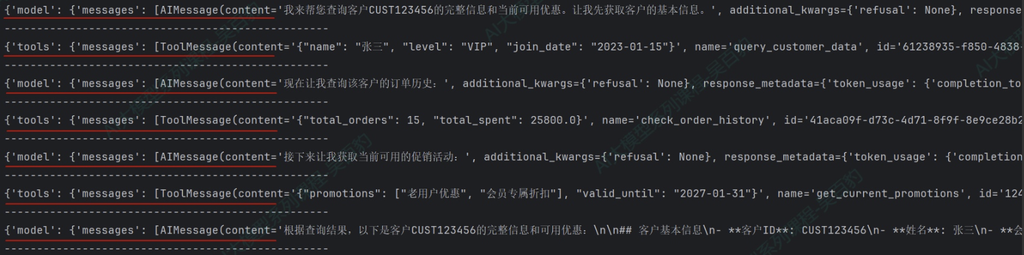

### 3）messages输出模式

该模式中会输出流式返回的Token以及相关的元数据（如：来自哪个节点），可以用在实现类似ChatGPT 的打字机效果场景，为聊天机器人等交互式应用提供最佳的实时体验。  
代码如下：

```python
from langchain.agents import create_agent
from langchain.tools import tool
from typing import Dict, Any
from rich import print as rprint
@tool
def query_customer_data(customer_id: str) -> Dict[str, Any]:
    """
    查询客户基本信息

    Args:
        customer_id: 客户ID，用于唯一标识客户

    Returns:
        包含客户基本信息的字典，如姓名、等级、加入日期等
    """
    # 模拟数据库查询
    return {"name": "张三","level": "VIP","join_date": "2023-01-15"}

@tool
def check_order_history(customer_id: str) -> Dict[str, Any]:
    """
    查询客户订单历史

    Args:
        customer_id: 客户ID，用于唯一标识客户

    Returns:
        包含客户订单历史的字典，如总订单数、总花费等
    """
    return {"total_orders": 15,"total_spent": 25800.00}

@tool
def get_current_promotions() -> Dict[str, Any]:
    """
    获取当前可用促销活动

    Returns:
        包含当前可用促销活动的字典，如活动名称、有效日期等
    """
    return {
        "promotions": ["老用户优惠", "会员专属折扣"],
        "valid_until": "2027-01-31"
    }

# 创建客户服务Agent
customer_service_agent = create_agent(
    model=model,
    tools=[query_customer_data, check_order_history, get_current_promotions]
)

for chunk in customer_service_agent.stream(
    {"messages": [{"role": "user","content": "查询客户ID为 CUST123456 的个人信息、历史订单和可用优惠"}]},
    stream_mode="messages"
):
    # rprint(chunk)
    # print("-" * 50)
    print(chunk[0].content,end="",flush=True)
```

```
我来为您查询客户 CUST123456 的个人信息、历史订单和可用优惠信息。让我同时发起这些查询。

{"name": "张三", "level": "VIP", "join_date": "2023-01-15"}{"total_orders": 15, "total_spent": 25800.0}{"promotions": ["老用户优惠", "会员专属折扣"], "valid_until": "2027-01-31"}我已成功查询到客户 CUST123456 的相关信息，以下是详细结果：

## 📋 客户个人信息
| 项目 | 详情 |
|------|------|
| **姓名** | 张三 |
| **会员等级** | VIP |
| **加入日期** | 2023年1月15日 |

## 🛒 历史订单信息
| 项目 | 详情 |
|------|------|
| **总订单数** | 15 笔 |
| **累计消费** | ¥25,800.00 |

## 🎁 可用优惠活动
| 项目 | 详情 |
|------|------|
| **可用优惠** | 老用户优惠、会员专属折扣 |
| **有效期至** | 2027年1月31日 |

---

**总结：** 客户张三是VIP会员，自2023年加入以来共完成15笔订单，累计消费25,800元。目前可享受"老用户优惠"和"会员专属折扣"两项优惠，有效期至2027年1月底。

如需进一步查询或操作，请随时告诉我！
```

### 4）tasks输出模式

```python
from langchain.agents import create_agent
from langchain.tools import tool
from typing import Dict, Any
from rich import print as rprint
@tool
def query_customer_data(customer_id: str) -> Dict[str, Any]:
    """
    查询客户基本信息

    Args:
        customer_id: 客户ID，用于唯一标识客户

    Returns:
        包含客户基本信息的字典，如姓名、等级、加入日期等
    """
    # 模拟数据库查询
    return {"name": "张三","level": "VIP","join_date": "2023-01-15"}

@tool
def check_order_history(customer_id: str) -> Dict[str, Any]:
    """
    查询客户订单历史

    Args:
        customer_id: 客户ID，用于唯一标识客户

    Returns:
        包含客户订单历史的字典，如总订单数、总花费等
    """
    return {"total_orders": 15,"total_spent": 25800.00}

@tool
def get_current_promotions() -> Dict[str, Any]:
    """
    获取当前可用促销活动

    Returns:
        包含当前可用促销活动的字典，如活动名称、有效日期等
    """
    return {
        "promotions": ["老用户优惠", "会员专属折扣"],
        "valid_until": "2027-01-31"
    }

# 创建客户服务Agent
customer_service_agent = create_agent(
    model=model,
    tools=[query_customer_data, check_order_history, get_current_promotions]
)

for chunk in customer_service_agent.stream(
    {"messages": [{"role": "user","content": "查询客户ID为 CUST123456 的个人信息、历史订单和可用优惠"}]},
    stream_mode="tasks"
):
    rprint(chunk)
    print("-" * 50)
```

```
{
    'id': '5abf172f-d530-f4cc-6ae3-5b9c51788073',
    'name': 'model',
    'input': {
        'messages': [
            HumanMessage(
                content='查询客户ID为 CUST123456 的个人信息、历史订单和可用优惠',
                additional_kwargs={},
                response_metadata={},
                id='cc503bf0-acae-41ef-bf20-cc152b9296fd'
            )
        ]
    },
    'triggers': ('branch:to:model',)
}
```

```
{
    'id': '5abf172f-d530-f4cc-6ae3-5b9c51788073',
    'name': 'model',
    'error': None,
    'result': {
        'messages': [
            AIMessage(
                content='我来帮您查询客户 CUST123456
的个人信息、历史订单和可用优惠。这三个查询是独立的，我将同时进行查询',
                additional_kwargs={'refusal': None},
                response_metadata={
                    'token_usage': {
                        'completion_tokens': 130,
                        'prompt_tokens': 467,
                        'total_tokens': 597,
                        'completion_tokens_details': None,
                        'prompt_tokens_details': {'audio_tokens': None, 'cached_tokens': 0}
                    },
                    'model_provider': 'openai',
                    'model_name': 'deepseek-v4-flash-0731',
                    'system_fingerprint': None,
                    'id': 'chatcmpl-050cdd80-6a88-90d7-a003-e9bbef0dd06c',
                    'finish_reason': 'tool_calls',
                    'logprobs': None
                },
                id='lc_run--019ff659-3d22-75c3-a031-b10e0265a688-0',
                tool_calls=[
                    {
                        'name': 'query_customer_data',
                        'args': {'customer_id': 'CUST123456'},
                        'id': 'call_4ba175f4d1be470099640739',
                        'type': 'tool_call'
                    },
                    {
                        'name': 'check_order_history',
                        'args': {'customer_id': 'CUST123456'},
                        'id': 'call_0fc49e45b1fd4432b268d94a',
                        'type': 'tool_call'
                    },
                    {
                        'name': 'get_current_promotions',
                        'args': {},
                        'id': 'call_77a08215fce9428d8bf96a5f',
                        'type': 'tool_call'
                    }
                ],
                invalid_tool_calls=[],
                usage_metadata={
                    'input_tokens': 467,
                    'output_tokens': 130,
                    'total_tokens': 597,
                    'input_token_details': {'cache_read': 0},
                    'output_token_details': {}
                }
            )
        ]
    },
    'interrupts': []
}
```

```
{
    'id': 'bf5bf44a-fd3a-5e93-e6a3-39071c79927c',
    'name': 'tools',
    'input': {
        '__type': 'tool_call_with_context',
        'tool_call': {
            'name': 'query_customer_data',
            'args': {'customer_id': 'CUST123456'},
            'id': 'call_4ba175f4d1be470099640739',
            'type': 'tool_call'
        },
        'state': {
            'messages': [
                HumanMessage(
                    content='查询客户ID为 CUST123456 的个人信息、历史订单和可用优惠',
                    additional_kwargs={},
                    response_metadata={},
                    id='cc503bf0-acae-41ef-bf20-cc152b9296fd'
                ),
                AIMessage(
                    content='我来帮您查询客户 CUST123456
的个人信息、历史订单和可用优惠。这三个查询是独立的，我将同时进行查询',
                    additional_kwargs={'refusal': None},
                    response_metadata={
                        'token_usage': {
                            'completion_tokens': 130,
                            'prompt_tokens': 467,
                            'total_tokens': 597,
                            'completion_tokens_details': None,
                            'prompt_tokens_details': {'audio_tokens': None, 'cached_tokens': 0}
                        },
                        'model_provider': 'openai',
                        'model_name': 'deepseek-v4-flash-0731',
                        'system_fingerprint': None,
                        'id': 'chatcmpl-050cdd80-6a88-90d7-a003-e9bbef0dd06c',
                        'finish_reason': 'tool_calls',
                        'logprobs': None
                    },
                    id='lc_run--019ff659-3d22-75c3-a031-b10e0265a688-0',
                    tool_calls=[
```

[output cut: 18 more lines]

```
                    ],
                    invalid_tool_calls=[],
                    usage_metadata={
                        'input_tokens': 467,
                        'output_tokens': 130,
                        'total_tokens': 597,
                        'input_token_details': {'cache_read': 0},
                        'output_token_details': {}
                    }
                )
            ]
        }
    },
    'triggers': ('__pregel_push',)
}
```

```
{
    'id': '95521535-b010-7ef2-2f70-f8337c5f470e',
    'name': 'tools',
    'input': {
        '__type': 'tool_call_with_context',
        'tool_call': {
            'name': 'check_order_history',
            'args': {'customer_id': 'CUST123456'},
            'id': 'call_0fc49e45b1fd4432b268d94a',
            'type': 'tool_call'
        },
        'state': {
            'messages': [
                HumanMessage(
                    content='查询客户ID为 CUST123456 的个人信息、历史订单和可用优惠',
                    additional_kwargs={},
                    response_metadata={},
                    id='cc503bf0-acae-41ef-bf20-cc152b9296fd'
                ),
                AIMessage(
                    content='我来帮您查询客户 CUST123456
的个人信息、历史订单和可用优惠。这三个查询是独立的，我将同时进行查询',
                    additional_kwargs={'refusal': None},
                    response_metadata={
                        'token_usage': {
                            'completion_tokens': 130,
                            'prompt_tokens': 467,
                            'total_tokens': 597,
                            'completion_tokens_details': None,
                            'prompt_tokens_details': {'audio_tokens': None, 'cached_tokens': 0}
                        },
                        'model_provider': 'openai',
                        'model_name': 'deepseek-v4-flash-0731',
                        'system_fingerprint': None,
                        'id': 'chatcmpl-050cdd80-6a88-90d7-a003-e9bbef0dd06c',
                        'finish_reason': 'tool_calls',
                        'logprobs': None
                    },
                    id='lc_run--019ff659-3d22-75c3-a031-b10e0265a688-0',
                    tool_calls=[
```

[output cut: 18 more lines]

```
                    ],
                    invalid_tool_calls=[],
                    usage_metadata={
                        'input_tokens': 467,
                        'output_tokens': 130,
                        'total_tokens': 597,
                        'input_token_details': {'cache_read': 0},
                        'output_token_details': {}
                    }
                )
            ]
        }
    },
    'triggers': ('__pregel_push',)
}
```

```
{
    'id': '7ef8e151-3b6c-46b3-d2d6-cb41200b82a8',
    'name': 'tools',
    'input': {
        '__type': 'tool_call_with_context',
        'tool_call': {
            'name': 'get_current_promotions',
            'args': {},
            'id': 'call_77a08215fce9428d8bf96a5f',
            'type': 'tool_call'
        },
        'state': {
            'messages': [
                HumanMessage(
                    content='查询客户ID为 CUST123456 的个人信息、历史订单和可用优惠',
                    additional_kwargs={},
                    response_metadata={},
                    id='cc503bf0-acae-41ef-bf20-cc152b9296fd'
                ),
                AIMessage(
                    content='我来帮您查询客户 CUST123456
的个人信息、历史订单和可用优惠。这三个查询是独立的，我将同时进行查询',
                    additional_kwargs={'refusal': None},
                    response_metadata={
                        'token_usage': {
                            'completion_tokens': 130,
                            'prompt_tokens': 467,
                            'total_tokens': 597,
                            'completion_tokens_details': None,
                            'prompt_tokens_details': {'audio_tokens': None, 'cached_tokens': 0}
                        },
                        'model_provider': 'openai',
                        'model_name': 'deepseek-v4-flash-0731',
                        'system_fingerprint': None,
                        'id': 'chatcmpl-050cdd80-6a88-90d7-a003-e9bbef0dd06c',
                        'finish_reason': 'tool_calls',
                        'logprobs': None
                    },
                    id='lc_run--019ff659-3d22-75c3-a031-b10e0265a688-0',
                    tool_calls=[
```

[output cut: 18 more lines]

```
                    ],
                    invalid_tool_calls=[],
                    usage_metadata={
                        'input_tokens': 467,
                        'output_tokens': 130,
                        'total_tokens': 597,
                        'input_token_details': {'cache_read': 0},
                        'output_token_details': {}
                    }
                )
            ]
        }
    },
    'triggers': ('__pregel_push',)
}
```

```
{
    'id': 'bf5bf44a-fd3a-5e93-e6a3-39071c79927c',
    'name': 'tools',
    'error': None,
    'result': {
        'messages': [
            ToolMessage(
                content='{"name": "张三", "level": "VIP", "join_date": "2023-01-15"}',
                name='query_customer_data',
                id='ff09b75f-4cda-4657-b417-0385d6d7de24',
                tool_call_id='call_4ba175f4d1be470099640739'
            )
        ]
    },
    'interrupts': []
}
```

```
{
    'id': '95521535-b010-7ef2-2f70-f8337c5f470e',
    'name': 'tools',
    'error': None,
    'result': {
        'messages': [
            ToolMessage(
                content='{"total_orders": 15, "total_spent": 25800.0}',
                name='check_order_history',
                id='7c434a02-ec08-41f5-8236-73db63b809bb',
                tool_call_id='call_0fc49e45b1fd4432b268d94a'
            )
        ]
    },
    'interrupts': []
}
```

```
{
    'id': '7ef8e151-3b6c-46b3-d2d6-cb41200b82a8',
    'name': 'tools',
    'error': None,
    'result': {
        'messages': [
            ToolMessage(
                content='{"promotions": ["老用户优惠", "会员专属折扣"], "valid_until": "2027-01-31"}',
                name='get_current_promotions',
                id='85272dcb-2b57-4706-91c9-4286a2d4d446',
                tool_call_id='call_77a08215fce9428d8bf96a5f'
            )
        ]
    },
    'interrupts': []
}
```

```
{
    'id': 'f13f0bcf-d104-1d5a-4470-bf2faf4c220d',
    'name': 'model',
    'input': {
        'messages': [
            HumanMessage(
                content='查询客户ID为 CUST123456 的个人信息、历史订单和可用优惠',
                additional_kwargs={},
                response_metadata={},
                id='cc503bf0-acae-41ef-bf20-cc152b9296fd'
            ),
            AIMessage(
                content='我来帮您查询客户 CUST123456
的个人信息、历史订单和可用优惠。这三个查询是独立的，我将同时进行查询',
                additional_kwargs={'refusal': None},
                response_metadata={
                    'token_usage': {
                        'completion_tokens': 130,
                        'prompt_tokens': 467,
                        'total_tokens': 597,
                        'completion_tokens_details': None,
                        'prompt_tokens_details': {'audio_tokens': None, 'cached_tokens': 0}
                    },
                    'model_provider': 'openai',
                    'model_name': 'deepseek-v4-flash-0731',
                    'system_fingerprint': None,
                    'id': 'chatcmpl-050cdd80-6a88-90d7-a003-e9bbef0dd06c',
                    'finish_reason': 'tool_calls',
                    'logprobs': None
                },
                id='lc_run--019ff659-3d22-75c3-a031-b10e0265a688-0',
                tool_calls=[
                    {
                        'name': 'query_customer_data',
                        'args': {'customer_id': 'CUST123456'},
                        'id': 'call_4ba175f4d1be470099640739',
                        'type': 'tool_call'
                    },
                    {
                        'name': 'check_order_history',
```

[output cut: 27 more lines]

```
                content='{"total_orders": 15, "total_spent": 25800.0}',
                name='check_order_history',
                id='7c434a02-ec08-41f5-8236-73db63b809bb',
                tool_call_id='call_0fc49e45b1fd4432b268d94a'
            ),
            ToolMessage(
                content='{"promotions": ["老用户优惠", "会员专属折扣"], "valid_until": "2027-01-31"}',
                name='get_current_promotions',
                id='85272dcb-2b57-4706-91c9-4286a2d4d446',
                tool_call_id='call_77a08215fce9428d8bf96a5f'
            )
        ]
    },
    'triggers': ('branch:to:model',)
}
```

```
{
    'id': 'f13f0bcf-d104-1d5a-4470-bf2faf4c220d',
    'name': 'model',
    'error': None,
    'result': {
        'messages': [
            AIMessage(
                content='我已经成功查询到了客户 CUST123456 的相关信息，以下是汇总结果：\n\n## 📋 客户个人信息\n|
项目 | 详情 |\n|------|------|\n| **姓名** | 张三 |\n| **会员等级** | VIP |\n| **加入日期** | 2023-01-15 |\n\n## 🛒
订单历史\n| 项目 | 详情 |\n|------|------|\n| **总订单数** | 15 单 |\n| **总消费金额** | ¥25,800.00 |\n\n## 🎁
可用优惠\n| 项目 | 详情 |\n|------|------|\n| **可用促销活动** | ① 老用户优惠 ② 会员专属折扣 |\n| **有效期至** |
2027-01-31 |\n\n---\n\n**总结：** 客户张三是我司的 VIP 会员，自 2023 年加入以来共下单 15 次，累计消费
¥25,800。目前可享受"老用户优惠"和"会员专属折扣"两项促销活动，有效期至 2027 年 1
月底。\n\n如需进一步分析或查询其他信息，请随时告知！',
                additional_kwargs={'refusal': None},
                response_metadata={
                    'token_usage': {
                        'completion_tokens': 245,
                        'prompt_tokens': 693,
                        'total_tokens': 938,
                        'completion_tokens_details': None,
                        'prompt_tokens_details': {'audio_tokens': None, 'cached_tokens': 0}
                    },
                    'model_provider': 'openai',
                    'model_name': 'deepseek-v4-flash-0731',
                    'system_fingerprint': None,
                    'id': 'chatcmpl-0eef277b-0c17-98c6-9f01-da2653d48727',
                    'finish_reason': 'stop',
                    'logprobs': None
                },
                id='lc_run--019ff659-45fa-7d43-b705-a41151332dd5-0',
                tool_calls=[],
                invalid_tool_calls=[],
                usage_metadata={
                    'input_tokens': 693,
                    'output_tokens': 245,
                    'total_tokens': 938,
                    'input_token_details': {'cache_read': 0},
                    'output_token_details': {}
                }
            )
        ]
    },
    'interrupts': []
}
```

### 5）debug输出模式

该模式与tasks模式类似，比task模式多输出任务步骤、时间戳、task类型（task/task_result），该模式用于调试、监控task任务的生命周期。  
代码如下：

```python
from langchain.agents import create_agent
from langchain.tools import tool
from typing import Dict, Any
from rich import print as rprint
@tool
def query_customer_data(customer_id: str) -> Dict[str, Any]:
    """
    查询客户基本信息

    Args:
        customer_id: 客户ID，用于唯一标识客户

    Returns:
        包含客户基本信息的字典，如姓名、等级、加入日期等
    """
    # 模拟数据库查询
    return {"name": "张三","level": "VIP","join_date": "2023-01-15"}

@tool
def check_order_history(customer_id: str) -> Dict[str, Any]:
    """
    查询客户订单历史

    Args:
        customer_id: 客户ID，用于唯一标识客户

    Returns:
        包含客户订单历史的字典，如总订单数、总花费等
    """
    return {"total_orders": 15,"total_spent": 25800.00}

@tool
def get_current_promotions() -> Dict[str, Any]:
    """
    获取当前可用促销活动

    Returns:
        包含当前可用促销活动的字典，如活动名称、有效日期等
    """
    return {
        "promotions": ["老用户优惠", "会员专属折扣"],
        "valid_until": "2027-01-31"
    }

# 创建客户服务Agent
customer_service_agent = create_agent(
    model=model,
    tools=[query_customer_data, check_order_history, get_current_promotions]
)

for chunk in customer_service_agent.stream(
    {"messages": [{"role": "user","content": "查询客户ID为 CUST123456 的个人信息、历史订单和可用优惠"}]},
    stream_mode="debug"
):
    rprint(chunk)
    print("-" * 50)
```

```
{
    'step': 1,
    'timestamp': '2026-08-12T14:22:50.948154+00:00',
    'type': 'task',
    'payload': {
        'id': 'dff063c6-e6a2-a302-26d6-5586b5ce697f',
        'name': 'model',
        'input': {
            'messages': [
                HumanMessage(
                    content='查询客户ID为 CUST123456 的个人信息、历史订单和可用优惠',
                    additional_kwargs={},
                    response_metadata={},
                    id='4de03288-105d-4755-a9a9-45a306f47959'
                )
            ]
        },
        'triggers': ('branch:to:model',)
    }
}
```

```
{
    'step': 1,
    'timestamp': '2026-08-12T14:22:52.884443+00:00',
    'type': 'task_result',
    'payload': {
        'id': 'dff063c6-e6a2-a302-26d6-5586b5ce697f',
        'name': 'model',
        'error': None,
        'result': {
            'messages': [
                AIMessage(
                    content='我来为您查询客户 CUST123456 的个人信息、历史订单和可用优惠信息',
                    additional_kwargs={'refusal': None},
                    response_metadata={
                        'token_usage': {
                            'completion_tokens': 120,
                            'prompt_tokens': 467,
                            'total_tokens': 587,
                            'completion_tokens_details': None,
                            'prompt_tokens_details': {'audio_tokens': None, 'cached_tokens': 0}
                        },
                        'model_provider': 'openai',
                        'model_name': 'deepseek-v4-flash-0731',
                        'system_fingerprint': None,
                        'id': 'chatcmpl-f533b6e8-f1e3-9c36-ae1b-ec825d046a24',
                        'finish_reason': 'tool_calls',
                        'logprobs': None
                    },
                    id='lc_run--019ff65a-c254-78e2-8a78-ce7f2a8c1d8b-0',
                    tool_calls=[
                        {
                            'name': 'query_customer_data',
                            'args': {'customer_id': 'CUST123456'},
                            'id': 'call_6c38ec4791f14761b0a29123',
                            'type': 'tool_call'
                        },
                        {
                            'name': 'check_order_history',
                            'args': {'customer_id': 'CUST123456'},
                            'id': 'call_3fa0afdf50a94dcb9a1bce71',
```

[output cut: 8 more lines]

```
                    ],
                    invalid_tool_calls=[],
                    usage_metadata={
                        'input_tokens': 467,
                        'output_tokens': 120,
                        'total_tokens': 587,
                        'input_token_details': {'cache_read': 0},
                        'output_token_details': {}
                    }
                )
            ]
        },
        'interrupts': []
    }
}
```

```
{
    'step': 2,
    'timestamp': '2026-08-12T14:22:52.884443+00:00',
    'type': 'task',
    'payload': {
        'id': 'c51b9484-725d-3388-7ed9-6e53766a93db',
        'name': 'tools',
        'input': {
            '__type': 'tool_call_with_context',
            'tool_call': {
                'name': 'query_customer_data',
                'args': {'customer_id': 'CUST123456'},
                'id': 'call_6c38ec4791f14761b0a29123',
                'type': 'tool_call'
            },
            'state': {
                'messages': [
                    HumanMessage(
                        content='查询客户ID为 CUST123456 的个人信息、历史订单和可用优惠',
                        additional_kwargs={},
                        response_metadata={},
                        id='4de03288-105d-4755-a9a9-45a306f47959'
                    ),
                    AIMessage(
                        content='我来为您查询客户 CUST123456 的个人信息、历史订单和可用优惠信息',
                        additional_kwargs={'refusal': None},
                        response_metadata={
                            'token_usage': {
                                'completion_tokens': 120,
                                'prompt_tokens': 467,
                                'total_tokens': 587,
                                'completion_tokens_details': None,
                                'prompt_tokens_details': {'audio_tokens': None, 'cached_tokens': 0}
                            },
                            'model_provider': 'openai',
                            'model_name': 'deepseek-v4-flash-0731',
                            'system_fingerprint': None,
                            'id': 'chatcmpl-f533b6e8-f1e3-9c36-ae1b-ec825d046a24',
                            'finish_reason': 'tool_calls',
                            'logprobs': None
```

[output cut: 22 more lines]

```
                        invalid_tool_calls=[],
                        usage_metadata={
                            'input_tokens': 467,
                            'output_tokens': 120,
                            'total_tokens': 587,
                            'input_token_details': {'cache_read': 0},
                            'output_token_details': {}
                        }
                    )
                ]
            }
        },
        'triggers': ('__pregel_push',)
    }
}
```

```
{
    'step': 2,
    'timestamp': '2026-08-12T14:22:52.884443+00:00',
    'type': 'task',
    'payload': {
        'id': 'ba81389f-06a5-1096-cb13-e178c1bcf8eb',
        'name': 'tools',
        'input': {
            '__type': 'tool_call_with_context',
            'tool_call': {
                'name': 'check_order_history',
                'args': {'customer_id': 'CUST123456'},
                'id': 'call_3fa0afdf50a94dcb9a1bce71',
                'type': 'tool_call'
            },
            'state': {
                'messages': [
                    HumanMessage(
                        content='查询客户ID为 CUST123456 的个人信息、历史订单和可用优惠',
                        additional_kwargs={},
                        response_metadata={},
                        id='4de03288-105d-4755-a9a9-45a306f47959'
                    ),
                    AIMessage(
                        content='我来为您查询客户 CUST123456 的个人信息、历史订单和可用优惠信息',
                        additional_kwargs={'refusal': None},
                        response_metadata={
                            'token_usage': {
                                'completion_tokens': 120,
                                'prompt_tokens': 467,
                                'total_tokens': 587,
                                'completion_tokens_details': None,
                                'prompt_tokens_details': {'audio_tokens': None, 'cached_tokens': 0}
                            },
                            'model_provider': 'openai',
                            'model_name': 'deepseek-v4-flash-0731',
                            'system_fingerprint': None,
                            'id': 'chatcmpl-f533b6e8-f1e3-9c36-ae1b-ec825d046a24',
                            'finish_reason': 'tool_calls',
                            'logprobs': None
```

[output cut: 22 more lines]

```
                        invalid_tool_calls=[],
                        usage_metadata={
                            'input_tokens': 467,
                            'output_tokens': 120,
                            'total_tokens': 587,
                            'input_token_details': {'cache_read': 0},
                            'output_token_details': {}
                        }
                    )
                ]
            }
        },
        'triggers': ('__pregel_push',)
    }
}
```

```
{
    'step': 2,
    'timestamp': '2026-08-12T14:22:52.884443+00:00',
    'type': 'task',
    'payload': {
        'id': '45192082-a250-2db2-86a7-230ba2b95df1',
        'name': 'tools',
        'input': {
            '__type': 'tool_call_with_context',
            'tool_call': {
                'name': 'get_current_promotions',
                'args': {},
                'id': 'call_d1f587d2598b4ee0ab68e91c',
                'type': 'tool_call'
            },
            'state': {
                'messages': [
                    HumanMessage(
                        content='查询客户ID为 CUST123456 的个人信息、历史订单和可用优惠',
                        additional_kwargs={},
                        response_metadata={},
                        id='4de03288-105d-4755-a9a9-45a306f47959'
                    ),
                    AIMessage(
                        content='我来为您查询客户 CUST123456 的个人信息、历史订单和可用优惠信息',
                        additional_kwargs={'refusal': None},
                        response_metadata={
                            'token_usage': {
                                'completion_tokens': 120,
                                'prompt_tokens': 467,
                                'total_tokens': 587,
                                'completion_tokens_details': None,
                                'prompt_tokens_details': {'audio_tokens': None, 'cached_tokens': 0}
                            },
                            'model_provider': 'openai',
                            'model_name': 'deepseek-v4-flash-0731',
                            'system_fingerprint': None,
                            'id': 'chatcmpl-f533b6e8-f1e3-9c36-ae1b-ec825d046a24',
                            'finish_reason': 'tool_calls',
                            'logprobs': None
```

[output cut: 22 more lines]

```
                        invalid_tool_calls=[],
                        usage_metadata={
                            'input_tokens': 467,
                            'output_tokens': 120,
                            'total_tokens': 587,
                            'input_token_details': {'cache_read': 0},
                            'output_token_details': {}
                        }
                    )
                ]
            }
        },
        'triggers': ('__pregel_push',)
    }
}
```

```
{
    'step': 2,
    'timestamp': '2026-08-12T14:22:52.981045+00:00',
    'type': 'task_result',
    'payload': {
        'id': 'c51b9484-725d-3388-7ed9-6e53766a93db',
        'name': 'tools',
        'error': None,
        'result': {
            'messages': [
                ToolMessage(
                    content='{"name": "张三", "level": "VIP", "join_date": "2023-01-15"}',
                    name='query_customer_data',
                    id='0dfe608c-0715-48b4-a42c-8a75483d2cd2',
                    tool_call_id='call_6c38ec4791f14761b0a29123'
                )
            ]
        },
        'interrupts': []
    }
}
```

```
{
    'step': 2,
    'timestamp': '2026-08-12T14:22:52.991052+00:00',
    'type': 'task_result',
    'payload': {
        'id': 'ba81389f-06a5-1096-cb13-e178c1bcf8eb',
        'name': 'tools',
        'error': None,
        'result': {
            'messages': [
                ToolMessage(
                    content='{"total_orders": 15, "total_spent": 25800.0}',
                    name='check_order_history',
                    id='ec6404f1-83ad-4bbf-8fd3-df26ff8ad28f',
                    tool_call_id='call_3fa0afdf50a94dcb9a1bce71'
                )
            ]
        },
        'interrupts': []
    }
}
```

```
{
    'step': 2,
    'timestamp': '2026-08-12T14:22:53.003041+00:00',
    'type': 'task_result',
    'payload': {
        'id': '45192082-a250-2db2-86a7-230ba2b95df1',
        'name': 'tools',
        'error': None,
        'result': {
            'messages': [
                ToolMessage(
                    content='{"promotions": ["老用户优惠", "会员专属折扣"], "valid_until": "2027-01-31"}',
                    name='get_current_promotions',
                    id='5abae585-6958-4155-8d82-b5cb770525bf',
                    tool_call_id='call_d1f587d2598b4ee0ab68e91c'
                )
            ]
        },
        'interrupts': []
    }
}
```

```
{
    'step': 3,
    'timestamp': '2026-08-12T14:22:53.012040+00:00',
    'type': 'task',
    'payload': {
        'id': 'e099e702-0a69-6dc6-6e75-db2cbb810733',
        'name': 'model',
        'input': {
            'messages': [
                HumanMessage(
                    content='查询客户ID为 CUST123456 的个人信息、历史订单和可用优惠',
                    additional_kwargs={},
                    response_metadata={},
                    id='4de03288-105d-4755-a9a9-45a306f47959'
                ),
                AIMessage(
                    content='我来为您查询客户 CUST123456 的个人信息、历史订单和可用优惠信息',
                    additional_kwargs={'refusal': None},
                    response_metadata={
                        'token_usage': {
                            'completion_tokens': 120,
                            'prompt_tokens': 467,
                            'total_tokens': 587,
                            'completion_tokens_details': None,
                            'prompt_tokens_details': {'audio_tokens': None, 'cached_tokens': 0}
                        },
                        'model_provider': 'openai',
                        'model_name': 'deepseek-v4-flash-0731',
                        'system_fingerprint': None,
                        'id': 'chatcmpl-f533b6e8-f1e3-9c36-ae1b-ec825d046a24',
                        'finish_reason': 'tool_calls',
                        'logprobs': None
                    },
                    id='lc_run--019ff65a-c254-78e2-8a78-ce7f2a8c1d8b-0',
                    tool_calls=[
                        {
                            'name': 'query_customer_data',
                            'args': {'customer_id': 'CUST123456'},
                            'id': 'call_6c38ec4791f14761b0a29123',
                            'type': 'tool_call'
```

[output cut: 31 more lines]

```
                    name='check_order_history',
                    id='ec6404f1-83ad-4bbf-8fd3-df26ff8ad28f',
                    tool_call_id='call_3fa0afdf50a94dcb9a1bce71'
                ),
                ToolMessage(
                    content='{"promotions": ["老用户优惠", "会员专属折扣"], "valid_until": "2027-01-31"}',
                    name='get_current_promotions',
                    id='5abae585-6958-4155-8d82-b5cb770525bf',
                    tool_call_id='call_d1f587d2598b4ee0ab68e91c'
                )
            ]
        },
        'triggers': ('branch:to:model',)
    }
}
```

```
{
    'step': 3,
    'timestamp': '2026-08-12T14:22:56.260428+00:00',
    'type': 'task_result',
    'payload': {
        'id': 'e099e702-0a69-6dc6-6e75-db2cbb810733',
        'name': 'model',
        'error': None,
        'result': {
            'messages': [
                AIMessage(
                    content='我已经成功查询到客户 CUST123456 的相关信息，以下是详细结果：\n\n---\n\n## 📋
客户个人信息\n| 项目 | 内容 |\n|------|------|\n| **客户ID** | CUST123456 |\n| **姓名** | 张三 |\n| **会员等级** |
VIP |\n| **加入日期** | 2023-01-15 |\n\n---\n\n## 🛒 历史订单信息\n| 项目 | 内容 |\n|------|------|\n| **总订单数**
| 15 笔 |\n| **累计消费金额** | ¥25,800.00 |\n\n---\n\n## 🎁 当前可用优惠\n| 项目 | 内容 |\n|------|------|\n|
**可用促销活动** | ① 老用户优惠<br>② 会员专属折扣 |\n| **优惠有效期至** | 2027-01-31 |\n\n---\n\n### 📌 小结\n客户
**张三** 是 **VIP 等级** 会员，自 2023 年加入以来共完成 **15 笔订单**，累计消费 **¥25,800**。目前可享受
**老用户优惠** 和 **会员专属折扣** 两项促销活动，有效期至 2027 年 1 月 31
日。\n\n如需进一步了解订单详情或优惠具体内容，请随时告诉我！',
                    additional_kwargs={'refusal': None},
                    response_metadata={
                        'token_usage': {
                            'completion_tokens': 281,
                            'prompt_tokens': 683,
                            'total_tokens': 964,
                            'completion_tokens_details': None,
                            'prompt_tokens_details': {'audio_tokens': None, 'cached_tokens': 0}
                        },
                        'model_provider': 'openai',
                        'model_name': 'deepseek-v4-flash-0731',
                        'system_fingerprint': None,
                        'id': 'chatcmpl-8c805add-40c3-94e8-9f27-5c1d82374aee',
                        'finish_reason': 'stop',
                        'logprobs': None
                    },
                    id='lc_run--019ff65a-ca6a-77e1-8e01-218848286855-0',
                    tool_calls=[],
                    invalid_tool_calls=[],
                    usage_metadata={
                        'input_tokens': 683,
                        'output_tokens': 281,
                        'total_tokens': 964,
                        'input_token_details': {'cache_read': 0},
                        'output_token_details': {}
                    }
                )
            ]
        },
        'interrupts': []
    }
}
```

### 6）checkpoints输出模式

该模式中，每当检查点（checkpoint）被创建时会触发输出，输出包含检查点中的状态，用于需要状态持久化、工作流恢复或分布式执行跟踪的高级场景。

代码案例如下：

```python
from langgraph.checkpoint.memory import InMemorySaver
from langchain.agents import create_agent
from langchain.tools import tool
from typing import Dict, Any
from rich import print as rprint

@tool
def query_customer_data(customer_id: str) -> Dict[str, Any]:
    """
    查询客户基本信息

    Args:
        customer_id: 客户ID，用于唯一标识客户

    Returns:
        包含客户基本信息的字典，如姓名、等级、加入日期等
    """
    # 模拟数据库查询
    return {"name": "张三","level": "VIP","join_date": "2023-01-15"}

@tool
def check_order_history(customer_id: str) -> Dict[str, Any]:
    """
    查询客户订单历史

    Args:
        customer_id: 客户ID，用于唯一标识客户

    Returns:
        包含客户订单历史的字典，如总订单数、总花费等
    """
    return {"total_orders": 15,"total_spent": 25800.00}

@tool
def get_current_promotions() -> Dict[str, Any]:
    """
    获取当前可用促销活动

    Returns:
        包含当前可用促销活动的字典，如活动名称、有效日期等
    """
    return {
        "promotions": ["老用户优惠", "会员专属折扣"],
        "valid_until": "2027-01-31"
    }

# 1. 创建内存检查点存储
checkpointer = InMemorySaver()
# 2. 创建Agent
customer_service_agent = create_agent(
    model=model,
    tools=[query_customer_data, check_order_history, get_current_promotions],
    checkpointer=checkpointer # 启用检查点
)

# 3. 创建唯一的会话ID
config = {"configurable": {"thread_id": "session01"}}

# 4. 调用Agent
checkpoint_count = 0
# 使用checkpoints模式进行流式监控
for chunk in customer_service_agent.stream(
    {"messages": [{"role": "user","content": "查询客户ID为 CUST123456 的完整信息和可用优惠"}]},
    config=config,
    stream_mode="checkpoints"
):
    checkpoint_count += 1
    print(f"检查点 #{checkpoint_count}")
    print(chunk)
    print("-" * 50)
```

```
检查点 #1
{'config': {'configurable': {'checkpoint_ns': '', 'thread_id': 'session01', 'checkpoint_id': '1f19659b-b6cc-61de-bfff-a9cfe91edb35'}}, 'parent_config': None, 'values': {'messages': []}, 'metadata': {'source': 'input', 'step': -1, 'parents': {}}, 'next': ['__start__'], 'tasks': [{'id': 'cab75a35-2576…
--------------------------------------------------
检查点 #2
{'config': {'configurable': {'checkpoint_ns': '', 'thread_id': 'session01', 'checkpoint_id': '1f19659b-b6dd-62c9-8000-a1f00421f55f'}}, 'parent_config': {'configurable': {'checkpoint_ns': '', 'thread_id': 'session01', 'checkpoint_id': '1f19659b-b6cc-61de-bfff-a9cfe91edb35'}}, 'values': {'messages': […
--------------------------------------------------
检查点 #3
{'config': {'configurable': {'checkpoint_ns': '', 'thread_id': 'session01', 'checkpoint_id': '1f19659b-c956-6fb1-8001-cc0e6d5f6fc8'}}, 'parent_config': {'configurable': {'checkpoint_ns': '', 'thread_id': 'session01', 'checkpoint_id': '1f19659b-b6dd-62c9-8000-a1f00421f55f'}}, 'values': {'messages': […
--------------------------------------------------
检查点 #4
{'config': {'configurable': {'checkpoint_ns': '', 'thread_id': 'session01', 'checkpoint_id': '1f19659b-c97a-64af-8002-2f3dbb9face1'}}, 'parent_config': {'configurable': {'checkpoint_ns': '', 'thread_id': 'session01', 'checkpoint_id': '1f19659b-c956-6fb1-8001-cc0e6d5f6fc8'}}, 'values': {'messages': […
--------------------------------------------------
检查点 #5
{'config': {'configurable': {'checkpoint_ns': '', 'thread_id': 'session01', 'checkpoint_id': '1f19659b-e894-67c1-8003-cd4e201e3129'}}, 'parent_config': {'configurable': {'checkpoint_ns': '', 'thread_id': 'session01', 'checkpoint_id': '1f19659b-c97a-64af-8002-2f3dbb9face1'}}, 'values': {'messages': […
--------------------------------------------------
```

### 7）custom输出模式

开发者通过get_stream_writer 在工具或节点内部自定义发送的数据，用于输出业务逻辑相关的进度信息（如“已处理10/100条记录”）、自定义日志或指标。

举例：生成销售报告和库存报告Agent

```python
from langchain.agents import create_agent
from langgraph.config import get_stream_writer
from langchain.tools import tool
import time

@tool
def generate_sales_report() -> str:
    """生成销售报告"""
    writer = get_stream_writer()
    writer({"type": "生成销售报告", "message": "开始生成销售报告"})
    # 模拟数据处理
    for i in range(1, 4):
        time.sleep(0.5)
        writer({"type": "生成销售报告","message": f"生成销售报告进度百分比：{i *25}%"})

    writer({"type": "生成销售报告", "message": "报告生成完成"})

    return f"销售报告：总收入150万元，同比增长12%"

@tool
def generate_inventory_report() -> str:
    """生成库存报告"""
    writer = get_stream_writer()
    writer("开始库存分析...")
    time.sleep(0.5)
    writer("检查当前库存量...")
    time.sleep(0.5)
    writer("生成库存报告...")

    return "当前库存量为10000件，库存充足，无异常"


# 创建报告生成agent
reporting_agent = create_agent(
    model=model,
    tools=[generate_sales_report, generate_inventory_report]
)
for chunk in reporting_agent.stream(
    {"messages": [{"role": "user","content": "生成销售报告和库存报告"}]},
    stream_mode="custom"
):
    print(chunk)
    print("-" * 50)
```

```
{'type': '生成销售报告', 'message': '开始生成销售报告'}
--------------------------------------------------
开始库存分析...
--------------------------------------------------
{'type': '生成销售报告', 'message': '生成销售报告进度百分比：25%'}
--------------------------------------------------
检查当前库存量...
--------------------------------------------------
{'type': '生成销售报告', 'message': '生成销售报告进度百分比：50%'}
--------------------------------------------------
生成库存报告...
--------------------------------------------------
{'type': '生成销售报告', 'message': '生成销售报告进度百分比：75%'}
--------------------------------------------------
{'type': '生成销售报告', 'message': '报告生成完成'}
--------------------------------------------------
```

## 8.3 流式输出模式总结

如下是LangChain Agent输出模式对比：

[output not shown]

我们可以根据不同的目标来选择不同的输出模式。例如：

- 实现实时对话交互，优先选择messages模式；
- 观察Agent的思考与执行步骤，优先选择updates模式；
- 需要查看每一步状态优先选择values/tasks/debug模式；
- 在工具执行时输出自定义业务日志优先选择custom模式。

此外，**以上这些模式还可以组合使用，例如，可以同时指定stream_mode=[“tasks”，“updates”] ，这样在同一个循环里既能查看Agent task任务执行内容， 又能显示Agent每步的更新。**

举例：

```python
from langchain.agents import create_agent
from langchain.tools import tool
from typing import Dict, Any
from rich import print as rprint
@tool
def query_customer_data(customer_id: str) -> Dict[str, Any]:
    """
    查询客户基本信息

    Args:
        customer_id: 客户ID，用于唯一标识客户

    Returns:
        包含客户基本信息的字典，如姓名、等级、加入日期等
    """
    # 模拟数据库查询
    return {"name": "张三","level": "VIP","join_date": "2023-01-15"}

@tool
def check_order_history(customer_id: str) -> Dict[str, Any]:
    """
    查询客户订单历史

    Args:
        customer_id: 客户ID，用于唯一标识客户

    Returns:
        包含客户订单历史的字典，如总订单数、总花费等
    """
    return {"total_orders": 15,"total_spent": 25800.00}

@tool
def get_current_promotions() -> Dict[str, Any]:
    """
    获取当前可用促销活动

    Returns:
        包含当前可用促销活动的字典，如活动名称、有效日期等
    """
    return {
        "promotions": ["老用户优惠", "会员专属折扣"],
        "valid_until": "2027-01-31"
    }

# 创建客户服务Agent
customer_service_agent = create_agent(
    model=model,
    tools=[query_customer_data, check_order_history, get_current_promotions]
)

for stream_mode, chunk in customer_service_agent.stream(
    {"messages": [{"role": "user","content": "查询客户ID为 CUST123456 的个人信息、历史订单和可用优惠"}]},
    stream_mode=["tasks","updates"]
):
    rprint(f"当前流模式：{stream_mode},当前数据：{chunk}")
    print("-" * 50)
```

```
当前流模式：tasks,当前数据：{'id': 'acf00515-7129-6ac6-3dbb-5aa16861c25e', 'name': 'model', 'input': {'messages':
[HumanMessage(content='查询客户ID为 CUST123456 的个人信息、历史订单和可用优惠', additional_kwargs={},
response_metadata={}, id='8ae558fc-cd77-4cc6-935a-1f85d151c49f')]}, 'triggers': ('branch:to:model',)}
```

```
当前流模式：updates,当前数据：{'model': {'messages': [AIMessage(content='我来为您查询客户 CUST123456
的个人信息、历史订单和可用优惠信息。\n\n', additional_kwargs={'refusal': None}, response_metadata={'token_usage':
{'completion_tokens': 120, 'prompt_tokens': 467, 'total_tokens': 587, 'completion_tokens_details': None,
'prompt_tokens_details': {'audio_tokens': None, 'cached_tokens': 0}}, 'model_provider': 'openai', 'model_name':
'deepseek-v4-flash-0731', 'system_fingerprint': None, 'id': 'chatcmpl-bd803a1c-b5db-94f8-a59f-a084b4e1fa3a',
'finish_reason': 'tool_calls', 'logprobs': None}, id='lc_run--019ff667-1611-7641-986b-20c0a9b808c2-0',
tool_calls=[{'name': 'query_customer_data', 'args': {'customer_id': 'CUST123456'}, 'id':
'call_ff04aaac3dff41f9929f1f38', 'type': 'tool_call'}, {'name': 'check_order_history', 'args': {'customer_id':
'CUST123456'}, 'id': 'call_cf75141970ef4837a874a036', 'type': 'tool_call'}, {'name': 'get_current_promotions',
'args': {}, 'id': 'call_8b499bdd0ae145d488515c8d', 'type': 'tool_call'}], invalid_tool_calls=[],
usage_metadata={'input_tokens': 467, 'output_tokens': 120, 'total_tokens': 587, 'input_token_details':
{'cache_read': 0}, 'output_token_details': {}})]}}
```

```
当前流模式：tasks,当前数据：{'id': 'acf00515-7129-6ac6-3dbb-5aa16861c25e', 'name': 'model', 'error': None,
'result': {'messages': [AIMessage(content='我来为您查询客户 CUST123456 的个人信息、历史订单和可用优惠信息。\n\n',
additional_kwargs={'refusal': None}, response_metadata={'token_usage': {'completion_tokens': 120, 'prompt_tokens':
467, 'total_tokens': 587, 'completion_tokens_details': None, 'prompt_tokens_details': {'audio_tokens': None,
'cached_tokens': 0}}, 'model_provider': 'openai', 'model_name': 'deepseek-v4-flash-0731', 'system_fingerprint':
None, 'id': 'chatcmpl-bd803a1c-b5db-94f8-a59f-a084b4e1fa3a', 'finish_reason': 'tool_calls', 'logprobs': None},
id='lc_run--019ff667-1611-7641-986b-20c0a9b808c2-0', tool_calls=[{'name': 'query_customer_data', 'args':
{'customer_id': 'CUST123456'}, 'id': 'call_ff04aaac3dff41f9929f1f38', 'type': 'tool_call'}, {'name':
'check_order_history', 'args': {'customer_id': 'CUST123456'}, 'id': 'call_cf75141970ef4837a874a036', 'type':
'tool_call'}, {'name': 'get_current_promotions', 'args': {}, 'id': 'call_8b499bdd0ae145d488515c8d', 'type':
'tool_call'}], invalid_tool_calls=[], usage_metadata={'input_tokens': 467, 'output_tokens': 120, 'total_tokens':
587, 'input_token_details': {'cache_read': 0}, 'output_token_details': {}})]}, 'interrupts': []}
```

```
当前流模式：tasks,当前数据：{'id': '7e3cd596-721b-cfc7-222d-e1f75c5b9a4b', 'name': 'tools', 'input': {'__type':
'tool_call_with_context', 'tool_call': {'name': 'query_customer_data', 'args': {'customer_id': 'CUST123456'}, 'id':
'call_ff04aaac3dff41f9929f1f38', 'type': 'tool_call'}, 'state': {'messages': [HumanMessage(content='查询客户ID为
CUST123456 的个人信息、历史订单和可用优惠', additional_kwargs={}, response_metadata={},
id='8ae558fc-cd77-4cc6-935a-1f85d151c49f'), AIMessage(content='我来为您查询客户 CUST123456
的个人信息、历史订单和可用优惠信息。\n\n', additional_kwargs={'refusal': None}, response_metadata={'token_usage':
{'completion_tokens': 120, 'prompt_tokens': 467, 'total_tokens': 587, 'completion_tokens_details': None,
'prompt_tokens_details': {'audio_tokens': None, 'cached_tokens': 0}}, 'model_provider': 'openai', 'model_name':
'deepseek-v4-flash-0731', 'system_fingerprint': None, 'id': 'chatcmpl-bd803a1c-b5db-94f8-a59f-a084b4e1fa3a',
'finish_reason': 'tool_calls', 'logprobs': None}, id='lc_run--019ff667-1611-7641-986b-20c0a9b808c2-0',
tool_calls=[{'name': 'query_customer_data', 'args': {'customer_id': 'CUST123456'}, 'id':
'call_ff04aaac3dff41f9929f1f38', 'type': 'tool_call'}, {'name': 'check_order_history', 'args': {'customer_id':
'CUST123456'}, 'id': 'call_cf75141970ef4837a874a036', 'type': 'tool_call'}, {'name': 'get_current_promotions',
'args': {}, 'id': 'call_8b499bdd0ae145d488515c8d', 'type': 'tool_call'}], invalid_tool_calls=[],
usage_metadata={'input_tokens': 467, 'output_tokens': 120, 'total_tokens': 587, 'input_token_details':
{'cache_read': 0}, 'output_token_details': {}})]}}, 'triggers': ('__pregel_push',)}
```

```
当前流模式：tasks,当前数据：{'id': '44b8785f-f292-6b9c-e73c-e1e343c32ad3', 'name': 'tools', 'input': {'__type':
'tool_call_with_context', 'tool_call': {'name': 'check_order_history', 'args': {'customer_id': 'CUST123456'}, 'id':
'call_cf75141970ef4837a874a036', 'type': 'tool_call'}, 'state': {'messages': [HumanMessage(content='查询客户ID为
CUST123456 的个人信息、历史订单和可用优惠', additional_kwargs={}, response_metadata={},
id='8ae558fc-cd77-4cc6-935a-1f85d151c49f'), AIMessage(content='我来为您查询客户 CUST123456
的个人信息、历史订单和可用优惠信息。\n\n', additional_kwargs={'refusal': None}, response_metadata={'token_usage':
{'completion_tokens': 120, 'prompt_tokens': 467, 'total_tokens': 587, 'completion_tokens_details': None,
'prompt_tokens_details': {'audio_tokens': None, 'cached_tokens': 0}}, 'model_provider': 'openai', 'model_name':
'deepseek-v4-flash-0731', 'system_fingerprint': None, 'id': 'chatcmpl-bd803a1c-b5db-94f8-a59f-a084b4e1fa3a',
'finish_reason': 'tool_calls', 'logprobs': None}, id='lc_run--019ff667-1611-7641-986b-20c0a9b808c2-0',
tool_calls=[{'name': 'query_customer_data', 'args': {'customer_id': 'CUST123456'}, 'id':
'call_ff04aaac3dff41f9929f1f38', 'type': 'tool_call'}, {'name': 'check_order_history', 'args': {'customer_id':
'CUST123456'}, 'id': 'call_cf75141970ef4837a874a036', 'type': 'tool_call'}, {'name': 'get_current_promotions',
'args': {}, 'id': 'call_8b499bdd0ae145d488515c8d', 'type': 'tool_call'}], invalid_tool_calls=[],
usage_metadata={'input_tokens': 467, 'output_tokens': 120, 'total_tokens': 587, 'input_token_details':
{'cache_read': 0}, 'output_token_details': {}})]}}, 'triggers': ('__pregel_push',)}
```

```
当前流模式：tasks,当前数据：{'id': '9d617496-ce1f-3112-7617-489d3b6e75a9', 'name': 'tools', 'input': {'__type':
'tool_call_with_context', 'tool_call': {'name': 'get_current_promotions', 'args': {}, 'id':
'call_8b499bdd0ae145d488515c8d', 'type': 'tool_call'}, 'state': {'messages': [HumanMessage(content='查询客户ID为
CUST123456 的个人信息、历史订单和可用优惠', additional_kwargs={}, response_metadata={},
id='8ae558fc-cd77-4cc6-935a-1f85d151c49f'), AIMessage(content='我来为您查询客户 CUST123456
的个人信息、历史订单和可用优惠信息。\n\n', additional_kwargs={'refusal': None}, response_metadata={'token_usage':
{'completion_tokens': 120, 'prompt_tokens': 467, 'total_tokens': 587, 'completion_tokens_details': None,
'prompt_tokens_details': {'audio_tokens': None, 'cached_tokens': 0}}, 'model_provider': 'openai', 'model_name':
'deepseek-v4-flash-0731', 'system_fingerprint': None, 'id': 'chatcmpl-bd803a1c-b5db-94f8-a59f-a084b4e1fa3a',
'finish_reason': 'tool_calls', 'logprobs': None}, id='lc_run--019ff667-1611-7641-986b-20c0a9b808c2-0',
tool_calls=[{'name': 'query_customer_data', 'args': {'customer_id': 'CUST123456'}, 'id':
'call_ff04aaac3dff41f9929f1f38', 'type': 'tool_call'}, {'name': 'check_order_history', 'args': {'customer_id':
'CUST123456'}, 'id': 'call_cf75141970ef4837a874a036', 'type': 'tool_call'}, {'name': 'get_current_promotions',
'args': {}, 'id': 'call_8b499bdd0ae145d488515c8d', 'type': 'tool_call'}], invalid_tool_calls=[],
usage_metadata={'input_tokens': 467, 'output_tokens': 120, 'total_tokens': 587, 'input_token_details':
{'cache_read': 0}, 'output_token_details': {}})]}}, 'triggers': ('__pregel_push',)}
```

```
当前流模式：updates,当前数据：{'tools': {'messages': [ToolMessage(content='{"name": "张三", "level": "VIP",
"join_date": "2023-01-15"}', name='query_customer_data', id='b7b88b34-e545-4a38-855d-a826bcc1775e',
tool_call_id='call_ff04aaac3dff41f9929f1f38')]}}
```

```
当前流模式：tasks,当前数据：{'id': '7e3cd596-721b-cfc7-222d-e1f75c5b9a4b', 'name': 'tools', 'error': None,
'result': {'messages': [ToolMessage(content='{"name": "张三", "level": "VIP", "join_date": "2023-01-15"}',
name='query_customer_data', id='b7b88b34-e545-4a38-855d-a826bcc1775e',
tool_call_id='call_ff04aaac3dff41f9929f1f38')]}, 'interrupts': []}
```

```
当前流模式：updates,当前数据：{'tools': {'messages': [ToolMessage(content='{"total_orders": 15, "total_spent":
25800.0}', name='check_order_history', id='4c4cf726-af78-4f78-8093-4f1eef089dc3',
tool_call_id='call_cf75141970ef4837a874a036')]}}
```

```
当前流模式：tasks,当前数据：{'id': '44b8785f-f292-6b9c-e73c-e1e343c32ad3', 'name': 'tools', 'error': None,
'result': {'messages': [ToolMessage(content='{"total_orders": 15, "total_spent": 25800.0}',
name='check_order_history', id='4c4cf726-af78-4f78-8093-4f1eef089dc3',
tool_call_id='call_cf75141970ef4837a874a036')]}, 'interrupts': []}
```

```
当前流模式：updates,当前数据：{'tools': {'messages': [ToolMessage(content='{"promotions": ["老用户优惠",
"会员专属折扣"], "valid_until": "2027-01-31"}', name='get_current_promotions',
id='57fd1d0b-89d6-498c-a47f-9620dddb8932', tool_call_id='call_8b499bdd0ae145d488515c8d')]}}
```

```
当前流模式：tasks,当前数据：{'id': '9d617496-ce1f-3112-7617-489d3b6e75a9', 'name': 'tools', 'error': None,
'result': {'messages': [ToolMessage(content='{"promotions": ["老用户优惠", "会员专属折扣"], "valid_until":
"2027-01-31"}', name='get_current_promotions', id='57fd1d0b-89d6-498c-a47f-9620dddb8932',
tool_call_id='call_8b499bdd0ae145d488515c8d')]}, 'interrupts': []}
```

```
当前流模式：tasks,当前数据：{'id': '5e911902-64b2-1498-3036-a9293de59bb6', 'name': 'model', 'input': {'messages':
[HumanMessage(content='查询客户ID为 CUST123456 的个人信息、历史订单和可用优惠', additional_kwargs={},
response_metadata={}, id='8ae558fc-cd77-4cc6-935a-1f85d151c49f'), AIMessage(content='我来为您查询客户 CUST123456
的个人信息、历史订单和可用优惠信息。\n\n', additional_kwargs={'refusal': None}, response_metadata={'token_usage':
{'completion_tokens': 120, 'prompt_tokens': 467, 'total_tokens': 587, 'completion_tokens_details': None,
'prompt_tokens_details': {'audio_tokens': None, 'cached_tokens': 0}}, 'model_provider': 'openai', 'model_name':
'deepseek-v4-flash-0731', 'system_fingerprint': None, 'id': 'chatcmpl-bd803a1c-b5db-94f8-a59f-a084b4e1fa3a',
'finish_reason': 'tool_calls', 'logprobs': None}, id='lc_run--019ff667-1611-7641-986b-20c0a9b808c2-0',
tool_calls=[{'name': 'query_customer_data', 'args': {'customer_id': 'CUST123456'}, 'id':
'call_ff04aaac3dff41f9929f1f38', 'type': 'tool_call'}, {'name': 'check_order_history', 'args': {'customer_id':
'CUST123456'}, 'id': 'call_cf75141970ef4837a874a036', 'type': 'tool_call'}, {'name': 'get_current_promotions',
'args': {}, 'id': 'call_8b499bdd0ae145d488515c8d', 'type': 'tool_call'}], invalid_tool_calls=[],
usage_metadata={'input_tokens': 467, 'output_tokens': 120, 'total_tokens': 587, 'input_token_details':
{'cache_read': 0}, 'output_token_details': {}}), ToolMessage(content='{"name": "张三", "level": "VIP", "join_date":
"2023-01-15"}', name='query_customer_data', id='b7b88b34-e545-4a38-855d-a826bcc1775e',
tool_call_id='call_ff04aaac3dff41f9929f1f38'), ToolMessage(content='{"total_orders": 15, "total_spent": 25800.0}',
name='check_order_history', id='4c4cf726-af78-4f78-8093-4f1eef089dc3',
tool_call_id='call_cf75141970ef4837a874a036'), ToolMessage(content='{"promotions": ["老用户优惠", "会员专属折扣"],
"valid_until": "2027-01-31"}', name='get_current_promotions', id='57fd1d0b-89d6-498c-a47f-9620dddb8932',
tool_call_id='call_8b499bdd0ae145d488515c8d')]}, 'triggers': ('branch:to:model',)}
```

```
当前流模式：updates,当前数据：{'model': {'messages': [AIMessage(content='我已经成功查询到客户 CUST123456
的相关信息，以下是详细汇总：\n\n## 📋 客户个人信息\n- **姓名**：张三\n- **会员等级**：VIP\n-
**加入日期**：2023年1月15日\n\n## 🛒 历史订单信息\n- **总订单数**：15 单\n- **累计消费金额**：¥25,800.00\n\n## 🎁
当前可用优惠\n- **可用活动**：\n  1. 老用户优惠\n  2. 会员专属折扣\n- **优惠有效期**：至
2027年1月31日\n\n---\n\n**总结**：客户张三是一位 VIP
级别的老客户，自2023年1月加入以来共下单15次，累计消费25,800元。目前有两项优惠活动（老用户优惠和会员专属折扣）可供使
用，有效期至2027年1月31日。作为VIP客户，建议重点关注会员专属折扣，通常能为高消费客户带来更多优惠。如需进一步了解某
个优惠的具体内容，请随时告知！', additional_kwargs={'refusal': None}, response_metadata={'token_usage':
{'completion_tokens': 226, 'prompt_tokens': 684, 'total_tokens': 910, 'completion_tokens_details': None,
'prompt_tokens_details': {'audio_tokens': None, 'cached_tokens': 0}}, 'model_provider': 'openai', 'model_name':
'deepseek-v4-flash-0731', 'system_fingerprint': None, 'id': 'chatcmpl-f0de3639-b10e-9de4-8fc5-84f3a3b76884',
'finish_reason': 'stop', 'logprobs': None}, id='lc_run--019ff667-1f2e-7471-b86b-6836e42e8c29-0', tool_calls=[],
invalid_tool_calls=[], usage_metadata={'input_tokens': 684, 'output_tokens': 226, 'total_tokens': 910,
'input_token_details': {'cache_read': 0}, 'output_token_details': {}})]}}
```

```
当前流模式：tasks,当前数据：{'id': '5e911902-64b2-1498-3036-a9293de59bb6', 'name': 'model', 'error': None,
'result': {'messages': [AIMessage(content='我已经成功查询到客户 CUST123456 的相关信息，以下是详细汇总：\n\n## 📋
客户个人信息\n- **姓名**：张三\n- **会员等级**：VIP\n- **加入日期**：2023年1月15日\n\n## 🛒 历史订单信息\n-
**总订单数**：15 单\n- **累计消费金额**：¥25,800.00\n\n## 🎁 当前可用优惠\n- **可用活动**：\n  1. 老用户优惠\n  2.
会员专属折扣\n- **优惠有效期**：至 2027年1月31日\n\n---\n\n**总结**：客户张三是一位 VIP
级别的老客户，自2023年1月加入以来共下单15次，累计消费25,800元。目前有两项优惠活动（老用户优惠和会员专属折扣）可供使
用，有效期至2027年1月31日。作为VIP客户，建议重点关注会员专属折扣，通常能为高消费客户带来更多优惠。如需进一步了解某
个优惠的具体内容，请随时告知！', additional_kwargs={'refusal': None}, response_metadata={'token_usage':
{'completion_tokens': 226, 'prompt_tokens': 684, 'total_tokens': 910, 'completion_tokens_details': None,
'prompt_tokens_details': {'audio_tokens': None, 'cached_tokens': 0}}, 'model_provider': 'openai', 'model_name':
'deepseek-v4-flash-0731', 'system_fingerprint': None, 'id': 'chatcmpl-f0de3639-b10e-9de4-8fc5-84f3a3b76884',
'finish_reason': 'stop', 'logprobs': None}, id='lc_run--019ff667-1f2e-7471-b86b-6836e42e8c29-0', tool_calls=[],
invalid_tool_calls=[], usage_metadata={'input_tokens': 684, 'output_tokens': 226, 'total_tokens': 910,
'input_token_details': {'cache_read': 0}, 'output_token_details': {}})]}, 'interrupts': []}
```

当指定多模式后，可以通过“ for stream_mode, chunk in customer_service_agent.stream... ”来遍历dict，dict的key(stream_mode)是执行模式，value(chunk)是该模式输出的结果。

# 9.实战：多功能智能助手

项目需求：开发一个多功能智能助手，支持：

1. 天气查询：查询城市天气
2. 数学计算：复杂数学运算
3. 时间查询：获取当前时间、日期计算
4. 货币转换：多种货币之间转换
5. 信息搜索：搜索产品、新闻等信息

## 9.1 模型的初始化

```python
# 1、模型的初始化
import os
from dotenv import load_dotenv
from langchain.chat_models import init_chat_model

# 从.env文件中加载环境变量
load_dotenv(override=True)

# 模型的初始化
model = init_chat_model(
    model="deepseek-v4-flash",
    model_provider="deepseek",
    api_key=os.getenv("DEEPSEEK_API_KEY"),
    base_url=os.getenv("DEEPSEEK_BASE_URL")
)
```

## 9.2 工具的定义

```python
# ==================== 工具定义 ====================
from langchain_core.tools import tool
import math
from datetime import datetime, timedelta

@tool
def get_weather(city: str) -> str:
    """获取指定城市的实时天气信息
    支持中国主要城市的天气查询

    Args:
        city: 城市名称，如"北京"、"上海"、"深圳"等

    Returns:
        包含温度、天气状况、空气质量的详细信息

    Examples:
        get_weather("北京") 返回 "多云，15-22℃，空气质量良"
    """
    weather_db = {
        "北京": "多云，15-22℃，空气质量良，湿度 45%",
        "上海": "晴天，18-25℃，空气质量优，湿度 60%",
        "深圳": "小雨，22-28℃，空气质量优，湿度 75%",
        "成都": "阴天，16-23℃，空气质量良，湿度 70%",
        "杭州": "晴天，17-24℃，空气质量优，湿度 55%",
        "广州": "多云，21-29℃，空气质量良，湿度 72%"
    }

    result = weather_db.get(city)
    if result:
        return f"{city}：{result}"
    else:
        return f"抱歉，暂不支持查询{city}的天气信息。当前支持：北京、上海、深圳、成都、杭州、广州"

@tool
def calculator(expression: str) -> str:
    """执行数学计算
    支持基本运算符（+、-、*、/、**）和常用数学函数

    Args:
        expression: 数学表达式，可以包含：
            - 基本运算：2 + 3, 10 * 5, 100 / 4
            - 幂运算：2 ** 10
            - 函数：sqrt(16), abs(-5), pow(2, 3)

    Returns:
        计算结果或错误信息

    Examples:
        calculator("2 + 3 * 4") 返回 "14"
        calculator("sqrt(16)") 返回 "4.0"
    """
    try:
        # 安全的数学运算环境
        safe_functions = {
            "sqrt": math.sqrt,
            "pow": pow,
            "abs": abs,
            "round": round,
            "sin": math.sin,
            "cos": math.cos,
            "tan": math.tan,
            "log": math.log,
            "pi": math.pi,
            "e": math.e
        }

        result = eval(expression, {"__builtins__": {}}, safe_functions)
        return f"{expression} = {result}"
    except Exception as e:
        return f"计算出错：{str(e)}\n提示：请检查表达式格式，支持的函数有 sqrt,abs, pow, sin, cos, tan, log"


@tool
def get_time_info(query_type: str = "current") -> str:
    """获取时间相关信息

    Args:
        query_type: 查询类型
            - "current": 当前时间
            - "date": 今天日期
            - "tomorrow": 明天日期
            - "yesterday": 昨天日期
            - "weekday": 星期几

    Returns:
        时间信息字符串

    Examples:
        get_time_info("current") 返回 "2025年1月25日 14:30:25"
        get_time_info("weekday") 返回 "星期六"
    """
    now = datetime.now()

    if query_type == "current":
        return now.strftime("当前时间：%Y年%m月%d日 %H:%M:%S")
    elif query_type == "date":
        return now.strftime("今天是：%Y年%m月%d日")
    elif query_type == "tomorrow":
        tomorrow = now + timedelta(days=1)
        return tomorrow.strftime("明天是：%Y年%m月%d日")
    elif query_type == "yesterday":
        yesterday = now - timedelta(days=1)
        return yesterday.strftime("昨天是：%Y年%m月%d日")
    elif query_type == "weekday":
        weekdays = ["星期一", "星期二", "星期三", "星期四", "星期五", "星期六","星期日"]
        return f"今天是{weekdays[now.weekday()]}"
    else:
        return f"不支持的查询类型：{query_type}。支持：current, date, tomorrow,yesterday, weekday"


@tool
def convert_currency(amount: float, from_curr: str, to_curr: str) -> str:
    """货币转换工具
    支持主要货币之间的实时汇率转换

    Args:
        amount: 金额数值
        from_curr: 源货币代码（CNY/USD/EUR/GBP/JPY/HKD）
        to_curr: 目标货币代码（CNY/USD/EUR/GBP/JPY/HKD）

    Returns:
        转换结果

    Examples:
        convert_currency(100, "CNY", "USD") 返回 "100 CNY = 14.00 USD"
    """
    # 汇率表（相对于 CNY）
    exchange_rates = {
        "CNY": 1.0, # 人民币
        "USD": 0.14, # 美元
        "EUR": 0.13, # 欧元
        "GBP": 0.11, # 英镑
        "JPY": 20.8, # 日元
        "HKD": 1.09 # 港币
    }

    # 货币名称
    currency_names = {
        "CNY": "人民币", "USD": "美元", "EUR": "欧元",
        "GBP": "英镑", "JPY": "日元", "HKD": "港币"
    }

    from_curr = from_curr.upper()
    to_curr = to_curr.upper()

    if from_curr not in exchange_rates:
        return f"不支持的源货币：{from_curr}。支持的货币：CNY, USD, EUR, GBP,JPY, HKD"
    if to_curr not in exchange_rates:
        return f"不支持的目标货币：{to_curr}。支持的货币：CNY, USD, EUR, GBP,JPY, HKD"


    # 转换逻辑：先转为 CNY，再转为目标货币
    cny_amount = amount / exchange_rates[from_curr]
    result_amount = cny_amount * exchange_rates[to_curr]

    from_name = currency_names[from_curr]
    to_name = currency_names[to_curr]

    return f"{amount} {from_name}（{from_curr}）= {result_amount:.2f}{to_name}（{to_curr}）"


@tool
def search_info(keyword: str, category: str = "all") -> str:
    """搜索各类信息
    Args:
    keyword: 搜索关键词
    category: 搜索分类
    - "product": 搜索产品
    - "news": 搜索新闻
    - "all": 搜索所有
    Returns:
    搜索结果
    """
    # 模拟数据库
    products = {
        "手机": "iPhone 15 (¥5999), 小米14 (¥3999), 华为Mate60 (¥6999)",
        "笔记本": "MacBook Pro (¥12999), ThinkPad X1 (¥9999), 华为MateBook(¥7999)",
        "耳机": "AirPods Pro (¥1999), Sony WH-1000XM5 (¥2499)"
    }

    news = {
        "AI": "1. GPT-5 即将发布 2. AI 芯片市场增长 30% 3. 新AI法规出台",
        "科技": "1. 量子计算新突破 2. 6G 技术测试 3. 新能源汽车销量创新高"
    }

    results = []

    if category in ["product", "all"]:
        for key, value in products.items():
            if keyword in key:
                results.append(f"【产品】{key}：{value}")

    if category in ["news", "all"]:
        for key, value in news.items():
            if keyword in key or keyword in value:
                results.append(f"【新闻】{key} 相关：{value}")
    if results:
        return "\n".join(results)
    else:
        return f"未找到关于 '{keyword}' 的{category}信息"
```

## 9.3 agent的创建

```python
from langchain.agents import create_agent

class SmartAssistant:
    """多功能智能助手"""
    def __init__(self):
        # 初始化模型
        self.model = model

        # 工具列表
        self.tools = [
            get_weather,
            calculator,
            get_time_info,
            convert_currency,
            search_info
        ]

        # 系统提示词
        system_prompt = """你是一个多功能智能助手，可以帮助用户：
        🌤 查询天气：使用 get_weather 工具
        🔢 数学计算：使用 calculator 工具
        ⏰ 时间查询：使用 get_time_info 工具
        💱 货币转换：使用 convert_currency 工具
        🔍 信息搜索：使用 search_info 工具

        重要提示：
        1. 仔细阅读用户问题，确定需要使用哪个工具
        2. 如果需要多个工具，按顺序调用
        3. 总是用友好、专业的语气回答
        4. 如果工具返回了数据，要用通俗易懂的语言解释给用户
        5. 如果无法完成任务，诚实地告诉用户原因

        请始终使用中文回答。"""

        # ✅ 创建 agent
        self.agent = create_agent(
            model=self.model,
            tools=self.tools,
            system_prompt=system_prompt
        )

        # 对话历史
        self.messages = []

    def chat(self, user_input: str) -> str:
        """对话接口"""
        # 添加用户消息
        self.messages.append({"role": "user", "content": user_input})

        # 调用 agent
        result = self.agent.invoke({"messages": self.messages})

        # 更新消息历史
        self.messages = result["messages"]

        # 返回最后一条 AI 消息
        for msg in reversed(self.messages):
            if msg.type == "ai" and msg.content:
                return msg.content

        return "抱歉，我无法处理这个请求。"

    def reset(self):
        """重置对话历史"""
        self.messages = []
```

## 9.4 主程序

```python
# ==================== 主程序 ====================
def main():
    assistant = SmartAssistant()
    print("=" * 40)
    print("🤖 多功能智能助手（LangChain 1.2）")
    print("=" * 40)
    print("\n我可以帮你：")
    print(" 🌤 查询天气")
    print(" 🔢 数学计算")
    print(" ⏰ 时间查询")
    print(" 💱 货币转换")
    print(" 🔍 信息搜索")
    print("\n输入 'quit' 退出，输入 'reset' 重置对话\n")

    demos = [
        "北京今天天气怎么样？",
        "帮我算一下 (25 + 17) * 3",
        "现在几点了？",
        "100 美元等于多少人民币？"
    ]

    for demo in demos:
        print(f"👤 {demo}")
        response = assistant.chat(demo)
        print(f"🤖 {response}\n")

    # 重置对话
    assistant.reset()

    # 交互模式
    print("=" * 40)
    print("💬 进入交互模式")
    print("=" * 40)

    while True:
        user_input = input("\n👤 你: ")

        if user_input.lower() == 'quit':
            print("再见！👋")
            break

        if user_input.lower() == 'reset':
            assistant.reset()
            print("✅ 对话已重置")
            continue

        if not user_input.strip():
            continue
        # 调用助手
        response = assistant.chat(user_input)
        print(f"🤖 助手: {response}")


if __name__ == "__main__":
    main()
```

```
========================================
🤖 多功能智能助手（LangChain 1.2）
========================================

我可以帮你：
 🌤 查询天气
 🔢 数学计算
 ⏰ 时间查询
 💱 货币转换
 🔍 信息搜索

输入 'quit' 退出，输入 'reset' 重置对话

👤 北京今天天气怎么样？
🤖 好的！我帮您查询了北京的天气情况，以下是详细信息：

🌤 **北京今日天气**

- **天气状况**：多云
- **温度范围**：15℃ ~ 22℃
- **空气质量**：良 🟢
- **湿度**：45%

**温馨提示**：
- 今天温度比较舒适，适合外出活动，但早晚温差较大（15℃ vs 22℃），建议带一件薄外套🧥
- 多云天气，紫外线强度适中，如果长时间在户外还是可以适当防晒
- 空气质量良好，适合开窗通风和户外运动

请问还有其他需要帮助的吗？😊

👤 帮我算一下 (25 + 17) * 3
🤖 我帮您算好了！🧮

**(25 + 17) × 3 = 126**

计算过程如下：
1. 先算括号内的加法：25 + 17 = **42**
2. 再用结果乘以 3：42 × 3 = **126**

这个计算遵循了数学中的运算顺序规则——**先算括号，再做乘法**，最终结果是 **126**。
```

[output cut: 12 more lines]

```

**100 美元（USD）= 714.29 人民币（CNY）**

按照当前汇率，**1 美元 ≈ 7.14 人民币**。

**温馨提示**：
- 以上汇率仅供参考，实际兑换时银行或兑换机构可能会收取一定的手续费，汇率也会有细微浮动
- 建议在兑换前查看银行当天的实时牌价

还有其他需要帮助的吗？😊

========================================
💬 进入交互模式
========================================
再见！👋
```